# Part 3: Stocks Project

**Chapter 3: Single Hypothesis**

```r
library(readr)
df <- read_csv("volatility.csv")
head(df)
```

| VIX.Close | AAPL.Close | VXAPLCLS | VXAZNCLS | VXGOGCLS | GOOG.Close | AMZN.Close | GSPC.Close | Date | AAPL.Ret | AMZN.Ret | GOOG.Ret | GSPC.Ret | AAPL.Vol | AAPL.PVol | AMZN.PVol | GOOG.PVol | GSPC.PVol |
| --- | --- | --- | --- | --- | --- | --- | --- | --- | --- | --- | --- | --- | --- | --- | --- | --- | --- |
| 9.77 | 43.0650 | 24.25 | 26.59 | 20.29 | 1065.00 | 1189.01 | 2695.81 | 0 | 0.0177462274 | 0.016570407 | 0.0176190745 | 0.008269079 | 0.009281281 | 0.010094766 | 0.009585190 | 0.008515679 | 0.003848145 |
| 9.15 | 43.0575 | 24.47 | 26.15 | 20.69 | 1082.48 | 1204.20 | 2713.06 | 1 | -0.0001741705 | 0.012694369 | 0.0162798873 | 0.006378433 | 0.013203660 | 0.010035844 | 0.009467315 | 0.008510240 | 0.003968167 |
| 9.22 | 43.2575 | 23.88 | 26.45 | 21.55 | 1086.40 | 1209.59 | 2723.99 | 2 | 0.0046342202 | 0.004466026 | 0.0036148134 | 0.004020543 | 0.013895430 | 0.009918126 | 0.007285792 | 0.007812724 | 0.003974761 |
| 9.22 | 43.7500 | 24.46 | 26.15 | 21.89 | 1102.23 | 1229.14 | 2743.15 | 3 | 0.0113209841 | 0.016033319 | 0.0144658823 | 0.007009146 | 0.016809831 | 0.010162405 | 0.007785569 | 0.008127326 | 0.003957652 |
| 9.52 | 43.5875 | 25.15 | 27.83 | 23.20 | 1106.94 | 1246.87 | 2747.71 | 6 | -0.0037211549 | 0.014321657 | 0.0042640162 | 0.001660964 | 0.017276625 | 0.010162417 | 0.008041353 | 0.007880169 | 0.003928786 |
| 10.08 | 43.5825 | 25.23 | 28.04 | 21.19 | 1106.26 | 1252.70 | 2751.29 | 7 | -0.0001147643 | 0.004664776 | -0.0006144325 | 0.001302083 | 0.017995092 | 0.010167934 | 0.008021084 | 0.007702502 | 0.003927635 |

```r
attach(df)
```

Beta1 hypothesis tests for linearity

Null Hypothesis: Beta1 = 0; no relation between X and Y

Construct a 95% Confidence Interval for the value of Beta1

If the interval contains zero, then there is no linear relation

```r
mod <- lm(AAPL.Vol ~ AAPL.PVol)
CI_b11 = confint(mod)[2,]
CI_b11
```

```
##     2.5 %    97.5 %
## 0.2830332 0.4454848
```

```r
mod <- lm(AAPL.Vol ~ AMZN.PVol)
CI_b12 = confint(mod)[2,]
CI_b12
```

```
##     2.5 %    97.5 %
## 0.3295250 0.4377032
```

```r
mod <- lm(AAPL.Vol ~ GOOG.PVol)
CI_b13 = confint(mod)[2,]
CI_b13
```

```
##     2.5 %    97.5 %
## 0.3373554 0.5163088
```

```r
mod <- lm(AAPL.Vol ~ GSPC.PVol)
CI_b14 = confint(mod)[2,]
CI_b14
```

```
##     2.5 %    97.5 %
## 0.4453690 0.6912425
```

```r
mod <- lm(AAPL.Vol ~ AAPL.Close)
CI_b15 = confint(mod)[2,]
CI_b15
```

```
##         2.5 %        97.5 %
## -0.0002754410 -0.0001322303
```

```r
mod <- lm(AAPL.Vol ~ AMZN.Close)
CI_b16 = confint(mod)[2,]
CI_b16
```

```
##         2.5 %        97.5 %
## -7.829995e-06 -1.486254e-06
```

```r
mod <- lm(AAPL.Vol ~ GOOG.Close)
CI_b17 = confint(mod)[2,]
CI_b17
```

```
##         2.5 %        97.5 %
## -3.414044e-05 -2.186995e-05
```

```r
mod <- lm(AAPL.Vol ~ GSPC.Close)
CI_b18 = confint(mod)[2,]
CI_b18
```

```
##         2.5 %        97.5 %
## -1.742576e-05 -1.061455e-05
```

```r
mod <- lm(AAPL.Vol ~ VXAPLCLS)
CI_b19 = confint(mod)[2,]
CI_b19
```

```
##        2.5 %       97.5 %
## 0.0006454469 0.0007882949
```

```r
mod <- lm(AAPL.Vol ~ VXAZNCLS)
CI_b110 = confint(mod)[2,]
CI_b110
```

```
##        2.5 %       97.5 %
## 0.0005032842 0.0006014044
```

```r
mod <- lm(AAPL.Vol ~ VXGOGCLS)
CI_b111 = confint(mod)[2,]
CI_b111
```

```
##        2.5 %       97.5 %
## 0.0007002769 0.0008519949
```

```r
mod <- lm(AAPL.Vol ~ VIX.Close)
CI_b112 = confint(mod)[2,]
CI_b112
```

```
##        2.5 %       97.5 %
## 0.0006023719 0.0008418008
```

```r
mod <- lm(AAPL.Vol ~ AAPL.Ret)
CI_b113 = confint(mod)[2,]
CI_b113
```

```
##       2.5 %      97.5 %
## -0.10211976 -0.03977091
```

```r
mod <- lm(AAPL.Vol ~ AMZN.Ret)
CI_b114 = confint(mod)[2,]
CI_b114
```

```
##         2.5 %        97.5 %
## -0.0583337486 -0.0004114984
```

```r
mod <- lm(AAPL.Vol ~ GOOG.Ret)
CI_b115 = confint(mod)[2,]
CI_b115
```

```
##        2.5 %       97.5 %
## -0.060172750  0.006721432
```

```r
mod <- lm(AAPL.Vol ~ GSPC.Ret)
CI_b116 = confint(mod)[2,]
CI_b116
```

```
##      2.5 %     97.5 %
## -0.1510560 -0.0349265
```

Although the beta1 value for several of the linear regressions was very close to zero, the only variable for which we can be statistically certain has NO linear relation with AAPL.Vol is GOOG.Ret.

Pvol predictors have positive linear relation. Close predictors have negative linear relation with slope very close to zero. VIX predictors have a positive linear relation with slope very close to zero. Return variables have mostly negative relations, but GOOG.Ret has no linear relation with AAPL.Vol.

Chapter 9

```r
rm(list=ls())
library(corrplot)
df <- read.csv(file="./volatility.csv")
head(df)
```

|  | VIX.Close | AAPL.Close | VXAPLCLS | VXAZNCLS | VXGOGCLS | GOOG.Close | AMZN.Close | GSPC.Close | Date | AAPL.Ret | AMZN.Ret | GOOG.Ret | GSPC.Ret | AAPL.Vol | AAPL.PVol | AMZN.PVol | GOOG.PVol | GSPC.PVol |
| --- | --- | --- | --- | --- | --- | --- | --- | --- | --- | --- | --- | --- | --- | --- | --- | --- | --- | --- |
| 1 | 9.77 | 43.0650 | 24.25 | 26.59 | 20.29 | 1065.00 | 1189.01 | 2695.81 | 0 | 0.0177462274 | 0.016570407 | 0.0176190745 | 0.008269079 | 0.009281281 | 0.010094766 | 0.009585190 | 0.008515679 | 0.003848145 |
| 2 | 9.15 | 43.0575 | 24.47 | 26.15 | 20.69 | 1082.48 | 1204.20 | 2713.06 | 1 | -0.0001741705 | 0.012694369 | 0.0162798873 | 0.006378433 | 0.013203660 | 0.010035844 | 0.009467315 | 0.008510240 | 0.003968167 |
| 3 | 9.22 | 43.2575 | 23.88 | 26.45 | 21.55 | 1086.40 | 1209.59 | 2723.99 | 2 | 0.0046342202 | 0.004466026 | 0.0036148134 | 0.004020543 | 0.013895430 | 0.009918126 | 0.007285792 | 0.007812724 | 0.003974761 |
| 4 | 9.22 | 43.7500 | 24.46 | 26.15 | 21.89 | 1102.23 | 1229.14 | 2743.15 | 3 | 0.0113209841 | 0.016033319 | 0.0144658823 | 0.007009146 | 0.016809831 | 0.010162405 | 0.007785569 | 0.008127326 | 0.003957652 |
| 5 | 9.52 | 43.5875 | 25.15 | 27.83 | 23.20 | 1106.94 | 1246.87 | 2747.71 | 6 | -0.0037211549 | 0.014321657 | 0.0042640162 | 0.001660964 | 0.017276625 | 0.010162417 | 0.008041353 | 0.007880169 | 0.003928786 |
| 6 | 10.08 | 43.5825 | 25.23 | 28.04 | 21.19 | 1106.26 | 1252.70 | 2751.29 | 7 | -0.0001147643 | 0.004664776 | -0.0006144325 | 0.001302083 | 0.017995092 | 0.010167934 | 0.008021084 | 0.007702502 | 0.003927635 |

```r
AAPL.PVol = df$AAPL.PVol
GOOG.PVol = df$GOOG.PVol
AMZN.PVol = df$AMZN.PVol
GSPC.PVol = df$GSPC.PVol
VIX.Close = df$VIX.Close
AAPL.Close = df$AAPL.Close
VXAPLCLS = df$VXAPLCLS
VXAZNCLS = df$VXAZNCLS
VXGOGCLS = df$VXGOGCLS
GOOG.Close = df$GOOG.Close
AMZN.Close = df$AMZN.Close
GSPC.Close = df$GSPC.Close
Date = df$Date
AAPL.Ret = df$AAPL.Ret
AMZN.Ret = df$AMZN.Ret
GOOG.Ret = df$GOOG.Ret
GSPC.Ret = df$GSPC.Ret
AAPL.Vol = df$AAPL.Vol
```

```r
#install.packages("olsrr")
library("olsrr")
```

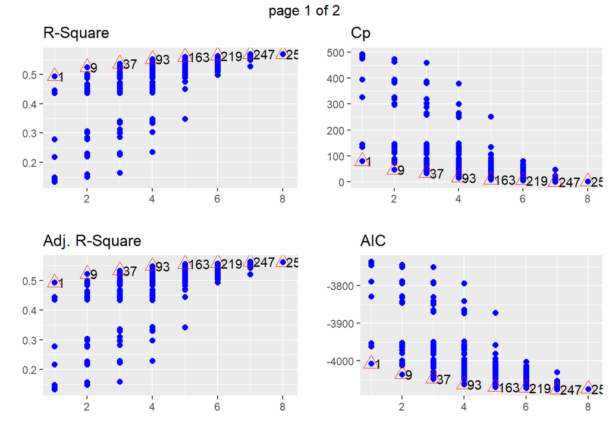

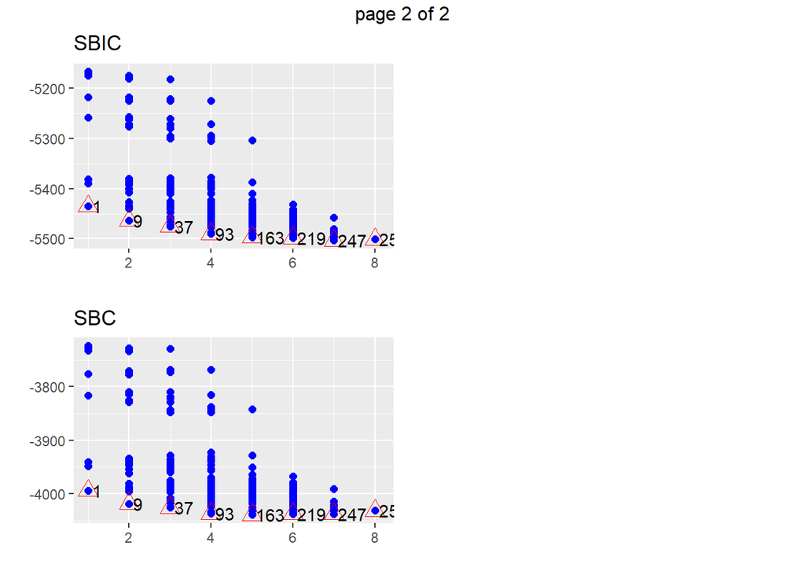

```r
mod <- lm(AAPL.Vol ~ VXAPLCLS+VXAZNCLS+VXGOGCLS+VIX.Close+AMZN.PVol+AAPL.PVol+AMZN.PVol+GOOG.PVol+GSPC.PVol, data=df)
k <- ols_step_all_possible(mod)
plot(k)
```

```r
k
```

|  | mindex | n | predictors | rsquare | adjr | predrsq | cp | aic | sbic | sbc | msep | fpe | apc | hsp |
| --- | --- | --- | --- | --- | --- | --- | --- | --- | --- | --- | --- | --- | --- | --- |
| 2 | 1 | 1 | VXAZNCLS | 0.4940836 | 0.4930738 | 0.4898580 | 81.238398 | -4006.854 | -5434.874 | -3994.192 | 0.010141256 | 2.024171e-05 | 0.5099557 | 4.032309e-08 |
| 3 | 2 | 1 | VXGOGCLS | 0.4464525 | 0.4453476 | 0.4419362 | 135.866810 | -3961.596 | -5389.965 | -3948.934 | 0.011096038 | 2.214743e-05 | 0.5579671 | 4.411943e-08 |
| 1 | 3 | 1 | VXAPLCLS | 0.4369883 | 0.4358646 | 0.4326778 | 146.721268 | -3953.069 | -5381.503 | -3940.407 | 0.011285749 | 2.252609e-05 | 0.5675068 | 4.487375e-08 |
| 5 | 4 | 1 | AMZN.PVol | 0.2793059 | 0.2778674 | 0.2732470 | 327.568136 | -3828.871 | -5258.195 | -3816.209 | 0.014446544 | 2.883496e-05 | 0.7264481 | 5.744152e-08 |
| 4 | 5 | 1 | VIX.Close | 0.2189415 | 0.2173825 | 0.2100135 | 396.800442 | -3788.412 | -5218.002 | -3775.750 | 0.015656568 | 3.125014e-05 | 0.7872945 | 6.225275e-08 |
| 7 | 6 | 1 | GOOG.PVol | 0.1491744 | 0.1474762 | 0.1422461 | 476.816700 | -3745.376 | -5175.236 | -3732.715 | 0.017055072 | 3.404152e-05 | 0.8576186 | 6.781340e-08 |
| 8 | 7 | 1 | GSPC.PVol | 0.1413725 | 0.1396587 | 0.1340289 | 485.764773 | -3740.785 | -5170.673 | -3728.123 | 0.017211464 | 3.435367e-05 | 0.8654828 | 6.843524e-08 |
| 6 | 8 | 1 | AAPL.PVol | 0.1341617 | 0.1324335 | 0.1264260 | 494.034839 | -3736.578 | -5166.492 | -3723.917 | 0.017356006 | 3.464218e-05 | 0.8727512 | 6.900996e-08 |
| 9 | 9 | 2 | VXAPLCLS VXAZNCLS | 0.5240224 | 0.5221185 | 0.5182902 | 48.901368 | -4035.537 | -5463.473 | -4018.655 | 0.009560243 | 1.911973e-05 | 0.4816893 | 3.808892e-08 |
| 21 | 10 | 2 | VXAZNCLS GSPC.PVol | 0.5011316 | 0.4991361 | 0.4955857 | 75.155032 | -4011.910 | -5440.117 | -3995.028 | 0.010020017 | 2.003924e-05 | 0.5048549 | 3.992070e-08 |

[output cut: 245 more lines]

```r
sub <- ols_step_best_subset(mod)
sub
```

|  | mindex | n | predictors | rsquare | adjr | predrsq | cp | aic | sbic | sbc | msep | fpe | apc | hsp |
| --- | --- | --- | --- | --- | --- | --- | --- | --- | --- | --- | --- | --- | --- | --- |
| 2 | 1 | 1 | VXAZNCLS | 0.4940836 | 0.4930738 | 0.4898580 | 81.238398 | -4006.854 | -5434.874 | -3994.192 | 0.010141256 | 2.024171e-05 | 0.5099557 | 4.032309e-08 |
| 9 | 2 | 2 | VXAPLCLS VXAZNCLS | 0.5240224 | 0.5221185 | 0.5182902 | 48.901368 | -4035.537 | -5463.473 | -4018.655 | 0.009560243 | 1.911973e-05 | 0.4816893 | 3.808892e-08 |
| 42 | 3 | 3 | VXAPLCLS VXAZNCLS GSPC.PVol | 0.5366805 | 0.5338950 | 0.5295311 | 36.383752 | -4047.095 | -5474.980 | -4025.992 | 0.009324686 | 1.868541e-05 | 0.4707475 | 3.722489e-08 |
| 107 | 4 | 4 | VXAPLCLS VXAZNCLS GOOG.PVol GSPC.PVol | 0.5524553 | 0.5488605 | 0.5437646 | 20.291571 | -4062.519 | -5490.173 | -4037.196 | 0.009025329 | 1.812114e-05 | 0.4565316 | 3.610218e-08 |
| 178 | 5 | 5 | VXAPLCLS VXAZNCLS VIX.Close GOOG.PVol GSPC.PVol | 0.5600910 | 0.5556654 | 0.5501100 | 13.534129 | -4069.175 | -5496.664 | -4039.631 | 0.008889231 | 1.788294e-05 | 0.4505305 | 3.562932e-08 |
| 231 | 6 | 6 | VXAPLCLS VXAZNCLS VIX.Close AMZN.PVol GOOG.PVol GSPC.PVol | 0.5637213 | 0.5584438 | 0.5514904 | 11.370498 | -4071.343 | -5498.722 | -4037.578 | 0.008833683 | 1.780604e-05 | 0.4485930 | 3.547806e-08 |
| 252 | 7 | 7 | VXAPLCLS VXAZNCLS VIX.Close AMZN.PVol AAPL.PVol GOOG.PVol GSPC.PVol | 0.5692554 | 0.5631641 | 0.5554372 | 7.023372 | -4075.764 | -5502.927 | -4037.779 | 0.008739284 | 1.765022e-05 | 0.4446676 | 3.516984e-08 |
| 255 | 8 | 8 | VXAPLCLS VXAZNCLS VXGOGCLS VIX.Close AMZN.PVol AAPL.PVol GOOG.PVol GSPC.PVol | 0.5692758 | 0.5623005 | 0.5532908 | 9.000000 | -4073.788 | -5500.913 | -4031.582 | 0.008756596 | 1.771973e-05 | 0.4464186 | 3.531084e-08 |

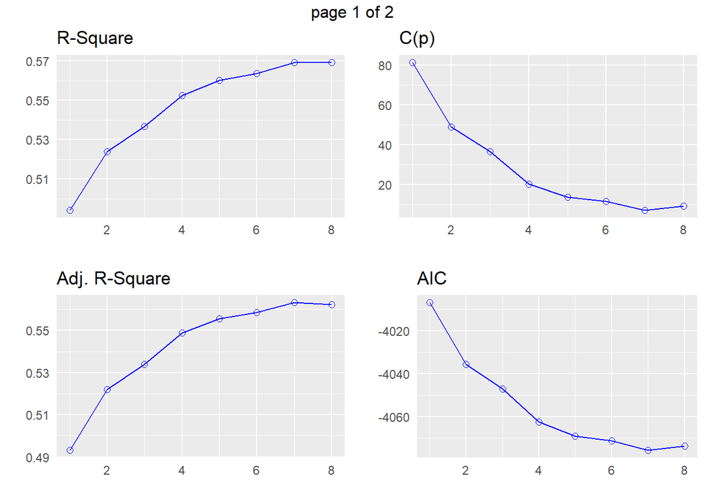

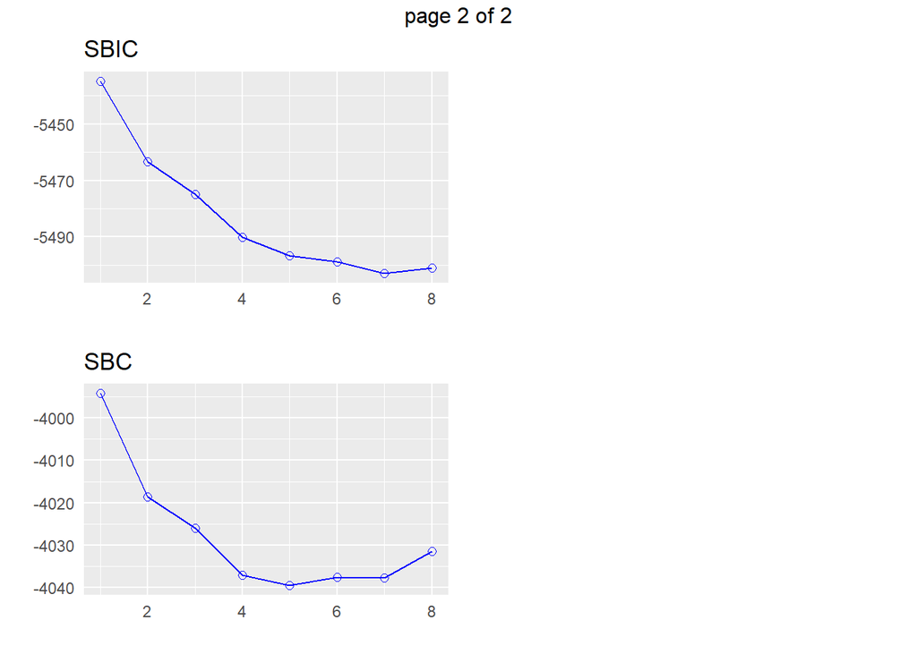

```r
plot(sub)
```

Forward Regression:

```r
ols_step_forward_p(mod, details = TRUE)
```

```
## Forward Selection Method
## ---------------------------
##
## Candidate Terms:
##
## 1. VXAPLCLS
## 2. VXAZNCLS
## 3. VXGOGCLS
## 4. VIX.Close
## 5. AMZN.PVol
## 6. AAPL.PVol
## 7. GOOG.PVol
## 8. GSPC.PVol
##
## We are selecting variables based on p value...
##
##
## Forward Selection: Step 1
##
## - VXAZNCLS
##
##                         Model Summary
## --------------------------------------------------------------
## R                       0.703       RMSE                0.004
## R-Squared               0.494       Coef. Var          27.681
## Adj. R-Squared          0.493       MSE                 0.000
## Pred R-Squared          0.490       MAE                 0.004
## --------------------------------------------------------------
##  RMSE: Root Mean Square Error
##  MSE: Mean Square Error
##  MAE: Mean Absolute Error
##
##                                 ANOVA
## ---------------------------------------------------------------------
##                Sum of
##               Squares         DF    Mean Square       F         Sig.
## ---------------------------------------------------------------------
## Regression      0.010          1          0.010    489.282    0.0000
## Residual        0.010        501          0.000
## Total           0.020        502
```

[output cut: 278 more lines]

```
## --------------------------------------------------------------------
##
##                                   Parameter Estimates
## ----------------------------------------------------------------------------------------
##       model      Beta    Std. Error    Std. Beta      t        Sig      lower     upper
## ----------------------------------------------------------------------------------------
## (Intercept)    -0.004         0.001                 -3.406    0.001    -0.006    -0.002
##    VXAZNCLS     0.000         0.000        0.488     7.705    0.000     0.000     0.000
##    VXAPLCLS     0.000         0.000        0.379     7.282    0.000     0.000     0.001
##   GSPC.PVol    -0.398         0.102       -0.264    -3.893    0.000    -0.599    -0.197
##   GOOG.PVol     0.258         0.063        0.234     4.112    0.000     0.135     0.381
##   VIX.Close     0.000         0.000       -0.154    -2.807    0.005     0.000     0.000
##   AMZN.PVol     0.162         0.053        0.223     3.059    0.002     0.058     0.266
##   AAPL.PVol    -0.166         0.066       -0.167    -2.522    0.012    -0.296    -0.037
## ----------------------------------------------------------------------------------------
```

```
##
##                              Selection Summary
## ----------------------------------------------------------------------------
##         Variable                   Adj.
## Step     Entered     R-Square    R-Square     C(p)         AIC         RMSE
## ----------------------------------------------------------------------------
##    1    VXAZNCLS       0.4941      0.4931    81.2384    -4006.8538    0.0045
##    2    VXAPLCLS       0.5240      0.5221    48.9014    -4035.5372    0.0044
##    3    GSPC.PVol      0.5367      0.5339    36.3838    -4047.0950    0.0043
##    4    GOOG.PVol      0.5525      0.5489    20.2916    -4062.5191    0.0042
##    5    VIX.Close      0.5601      0.5557    13.5341    -4069.1750    0.0042
##    6    AMZN.PVol      0.5637      0.5584    11.3705    -4071.3432    0.0042
##    7    AAPL.PVol      0.5693      0.5632     7.0234    -4075.7645    0.0042
## ----------------------------------------------------------------------------
```

## Stepwise Backward Regression

```r
k <- ols_step_backward_p(mod, details=TRUE)
```

```
## Backward Elimination Method
## ---------------------------
##
## Candidate Terms:
##
## 1 . VXAPLCLS
## 2 . VXAZNCLS
## 3 . VXGOGCLS
## 4 . VIX.Close
## 5 . AMZN.PVol
## 6 . AAPL.PVol
## 7 . GOOG.PVol
## 8 . GSPC.PVol
##
## We are eliminating variables based on p value...
##
## - VXGOGCLS
##
## Backward Elimination: Step 1
##
##  Variable VXGOGCLS Removed
##
##                         Model Summary
## --------------------------------------------------------------
## R                       0.754       RMSE                0.004
## R-Squared               0.569       Coef. Var          25.696
## Adj. R-Squared          0.563       MSE                 0.000
## Pred R-Squared          0.555       MAE                 0.003
## --------------------------------------------------------------
##  RMSE: Root Mean Square Error
##  MSE: Mean Square Error
##  MAE: Mean Absolute Error
##
##                                ANOVA
## --------------------------------------------------------------------
##                Sum of
##               Squares         DF    Mean Square      F         Sig.
## --------------------------------------------------------------------
## Regression      0.011          7          0.002    93.453    0.0000
## Residual        0.009        495          0.000
```

[output cut: 49 more lines]

```
## --------------------------------------------------------------------
##
##                                   Parameter Estimates
## ----------------------------------------------------------------------------------------
##       model      Beta    Std. Error    Std. Beta      t        Sig      lower     upper
## ----------------------------------------------------------------------------------------
## (Intercept)    -0.004         0.001                 -3.406    0.001    -0.006    -0.002
##    VXAPLCLS     0.000         0.000        0.379     7.282    0.000     0.000     0.001
##    VXAZNCLS     0.000         0.000        0.488     7.705    0.000     0.000     0.000
##   VIX.Close     0.000         0.000       -0.154    -2.807    0.005     0.000     0.000
##   AMZN.PVol     0.162         0.053        0.223     3.059    0.002     0.058     0.266
##   AAPL.PVol    -0.166         0.066       -0.167    -2.522    0.012    -0.296    -0.037
##   GOOG.PVol     0.258         0.063        0.234     4.112    0.000     0.135     0.381
##   GSPC.PVol    -0.398         0.102       -0.264    -3.893    0.000    -0.599    -0.197
## ----------------------------------------------------------------------------------------
```

```r
k
```

```
##
##
##                            Elimination Summary
## --------------------------------------------------------------------------
##         Variable                  Adj.
## Step    Removed     R-Square    R-Square     C(p)        AIC         RMSE
## --------------------------------------------------------------------------
##    1    VXGOGCLS      0.5693      0.5632    7.0234    -4075.7645    0.0042
## --------------------------------------------------------------------------
```

## Stepwise Regression

Build regression model from a set of candidate predictor variables by entering and removing predictors based on p values, in a stepwise manner until there is no variable left to enter or remove any more. The model should include all the candidate predictor variables. If details is set to `TRUE`, each step is displayed.

```r
ols_step_both_p(mod, details = TRUE)
```

```
## Stepwise Selection Method
## ---------------------------
##
## Candidate Terms:
##
## 1. VXAPLCLS
## 2. VXAZNCLS
## 3. VXGOGCLS
## 4. VIX.Close
## 5. AMZN.PVol
## 6. AAPL.PVol
## 7. GOOG.PVol
## 8. GSPC.PVol
##
## We are selecting variables based on p value...
##
##
## Stepwise Selection: Step 1
##
## - VXAZNCLS added
##
##                         Model Summary
## --------------------------------------------------------------
## R                       0.703       RMSE                0.004
## R-Squared               0.494       Coef. Var          27.681
## Adj. R-Squared          0.493       MSE                 0.000
## Pred R-Squared          0.490       MAE                 0.004
## --------------------------------------------------------------
##  RMSE: Root Mean Square Error
##  MSE: Mean Square Error
##  MAE: Mean Absolute Error
##
##                                 ANOVA
## ---------------------------------------------------------------------
##                Sum of
##               Squares         DF    Mean Square       F         Sig.
## ---------------------------------------------------------------------
## Regression      0.010          1          0.010    489.282    0.0000
## Residual        0.010        501          0.000
## Total           0.020        502
```

[output cut: 475 more lines]

```
## --------------------------------------------------------------------
##
##                                   Parameter Estimates
## ----------------------------------------------------------------------------------------
##       model      Beta    Std. Error    Std. Beta      t        Sig      lower     upper
## ----------------------------------------------------------------------------------------
## (Intercept)    -0.004         0.001                 -3.406    0.001    -0.006    -0.002
##    VXAZNCLS     0.000         0.000        0.488     7.705    0.000     0.000     0.000
##    VXAPLCLS     0.000         0.000        0.379     7.282    0.000     0.000     0.001
##   GSPC.PVol    -0.398         0.102       -0.264    -3.893    0.000    -0.599    -0.197
##   GOOG.PVol     0.258         0.063        0.234     4.112    0.000     0.135     0.381
##   VIX.Close     0.000         0.000       -0.154    -2.807    0.005     0.000     0.000
##   AMZN.PVol     0.162         0.053        0.223     3.059    0.002     0.058     0.266
##   AAPL.PVol    -0.166         0.066       -0.167    -2.522    0.012    -0.296    -0.037
## ----------------------------------------------------------------------------------------
```

```
##
##                                Stepwise Selection Summary
## ----------------------------------------------------------------------------------------
##                       Added/                   Adj.
## Step    Variable     Removed     R-Square    R-Square     C(p)         AIC         RMSE
## ----------------------------------------------------------------------------------------
##    1    VXAZNCLS     addition       0.494       0.493    81.2380    -4006.8538    0.0045
##    2    VXAPLCLS     addition       0.524       0.522    48.9010    -4035.5372    0.0044
##    3    GSPC.PVol    addition       0.537       0.534    36.3840    -4047.0950    0.0043
##    4    GOOG.PVol    addition       0.552       0.549    20.2920    -4062.5191    0.0042
##    5    VIX.Close    addition       0.560       0.556    13.5340    -4069.1750    0.0042
##    6    AMZN.PVol    addition       0.564       0.558    11.3700    -4071.3432    0.0042
##    7    AAPL.PVol    addition       0.569       0.563     7.0230    -4075.7645    0.0042
## ----------------------------------------------------------------------------------------
```

```r
new_mod <- lm(AAPL.Vol ~ VXAPLCLS+VXAZNCLS+VXGOGCLS+VIX.Close+AMZN.PVol, data=df)
k <- ols_step_both_p(new_mod, details = TRUE)
```

```
## Stepwise Selection Method
## ---------------------------
##
## Candidate Terms:
##
## 1. VXAPLCLS
## 2. VXAZNCLS
## 3. VXGOGCLS
## 4. VIX.Close
## 5. AMZN.PVol
##
## We are selecting variables based on p value...
##
##
## Stepwise Selection: Step 1
##
## - VXAZNCLS added
##
##                         Model Summary
## --------------------------------------------------------------
## R                       0.703       RMSE                0.004
## R-Squared               0.494       Coef. Var          27.681
## Adj. R-Squared          0.493       MSE                 0.000
## Pred R-Squared          0.490       MAE                 0.004
## --------------------------------------------------------------
##  RMSE: Root Mean Square Error
##  MSE: Mean Square Error
##  MAE: Mean Absolute Error
##
##                                 ANOVA
## ---------------------------------------------------------------------
##                Sum of
##               Squares         DF    Mean Square       F         Sig.
## ---------------------------------------------------------------------
## Regression      0.010          1          0.010    489.282    0.0000
## Residual        0.010        501          0.000
## Total           0.020        502
## ---------------------------------------------------------------------
##
##                                   Parameter Estimates
```

[output cut: 168 more lines]

```
## ---------------------------------------------------------------------
## Regression      0.011          3          0.004    191.694    0.0000
## Residual        0.009        499          0.000
## Total           0.020        502
## ---------------------------------------------------------------------
##
##                                   Parameter Estimates
## ----------------------------------------------------------------------------------------
##       model      Beta    Std. Error    Std. Beta      t        Sig      lower     upper
## ----------------------------------------------------------------------------------------
## (Intercept)    -0.003         0.001                 -3.237    0.001    -0.005    -0.001
##    VXAZNCLS     0.000         0.000        0.549    10.278    0.000     0.000     0.001
##    VXAPLCLS     0.000         0.000        0.339     6.483    0.000     0.000     0.000
##   VIX.Close     0.000         0.000       -0.160    -3.498    0.001     0.000     0.000
## ----------------------------------------------------------------------------------------
```

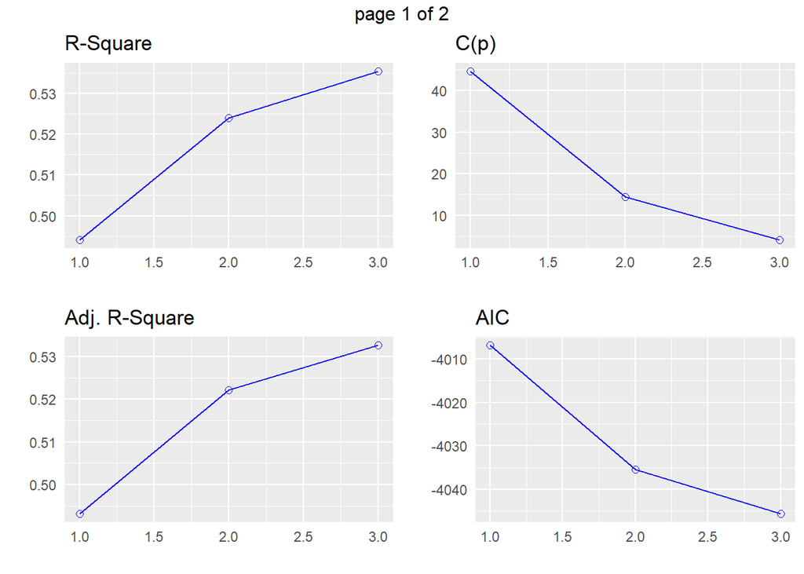

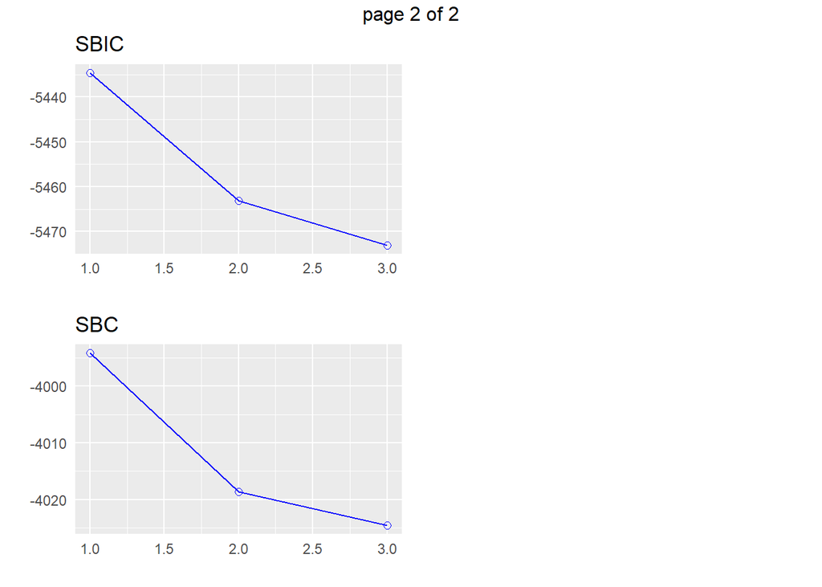

```r
plot(k)
```

```r
k
```

```
##
##                                Stepwise Selection Summary
## ----------------------------------------------------------------------------------------
##                       Added/                   Adj.
## Step    Variable     Removed     R-Square    R-Square     C(p)         AIC         RMSE
## ----------------------------------------------------------------------------------------
##    1    VXAZNCLS     addition       0.494       0.493    44.5640    -4006.8538    0.0045
##    2    VXAPLCLS     addition       0.524       0.522    14.3970    -4035.5372    0.0044
##    3    VIX.Close    addition       0.535       0.533     4.1540    -4045.7258    0.0043
## ----------------------------------------------------------------------------------------
```

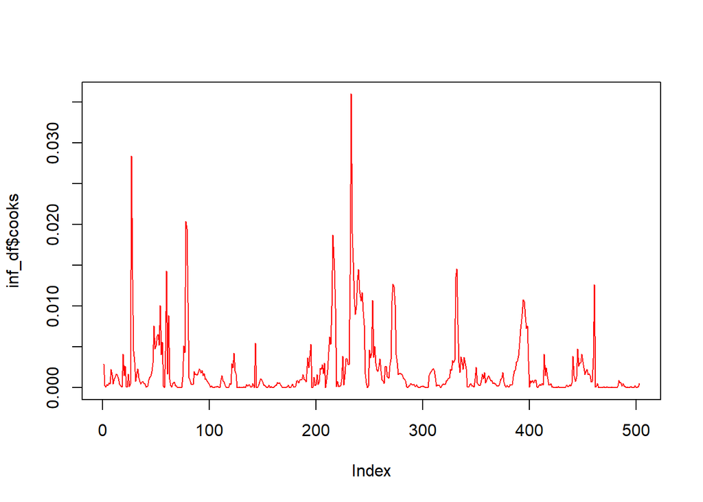

```r
m <- new_mod
inf_df <- data.frame(
  "dffits" = dffits(m),
  "cooks" = cooks.distance(m),
  "dfb1" = dfbetas(m)[,1],
  "dfb2" = dfbetas(m)[,2],
  "dfb3" = dfbetas(m)[,3],
  "dfb4" = dfbetas(m)[,4],
  "dfb5" = dfbetas(m)[,5]
)
plot(inf_df$cooks, type = "l",col="red")
```

**Chapter 8:**

```r
volatility_df <- read.csv("volatility.csv")
volatility_df$Date<-NULL
fit1<-lm(AAPL.Vol~.,volatility_df)
summary(fit1)
```

```
##
## Call:
## lm(formula = AAPL.Vol ~ ., data = volatility_df)
##
## Residuals:
##        Min         1Q     Median         3Q        Max
## -0.0088397 -0.0028762 -0.0002416  0.0022632  0.0165948
##
## Coefficients:
##               Estimate Std. Error t value Pr(>|t|)
## (Intercept) -3.744e-02  9.141e-03  -4.096 4.93e-05 ***
## VIX.Close   -1.497e-04  9.404e-05  -1.592 0.112078
## AAPL.Close  -6.918e-05  6.127e-05  -1.129 0.259388
## VXAPLCLS     2.560e-04  6.928e-05   3.695 0.000245 ***
## VXAZNCLS     4.842e-04  8.190e-05   5.912 6.38e-09 ***
## VXGOGCLS     6.316e-05  1.129e-04   0.560 0.576046
## GOOG.Close   5.568e-06  5.328e-06   1.045 0.296552
## AMZN.Close   3.077e-06  1.506e-06   2.043 0.041623 *
## GSPC.Close   8.004e-06  3.878e-06   2.064 0.039535 *
## AAPL.Ret    -1.439e-02  1.656e-02  -0.869 0.385400
## AMZN.Ret     3.271e-02  1.531e-02   2.137 0.033104 *
## GOOG.Ret     2.615e-02  1.818e-02   1.439 0.150882
## GSPC.Ret    -6.291e-02  4.008e-02  -1.570 0.117152
## AAPL.PVol   -2.104e-01  6.722e-02  -3.130 0.001851 **
## AMZN.PVol    2.110e-01  5.787e-02   3.645 0.000296 ***
## GOOG.PVol    2.831e-01  6.789e-02   4.169 3.62e-05 ***
## GSPC.PVol   -3.270e-01  1.129e-01  -2.896 0.003949 **
## ---
## Signif. codes:  0 '***' 0.001 '**' 0.01 '*' 0.05 '.' 0.1 ' ' 1
##
## Residual standard error: 0.00407 on 486 degrees of freedom
## Multiple R-squared:  0.5968, Adjusted R-squared:  0.5836
## F-statistic: 44.97 on 16 and 486 DF,  p-value: < 2.2e-16
```

```r
fit2<-lm(AAPL.Vol~VXAPLCLS+VXAZNCLS+AMZN.Close+GSPC.Close+AMZN.Ret+AAPL.PVol+AMZN.PVol+GOOG.PVol+GSPC.PVol,volatility_df)
summary(fit2)
```

```
##
## Call:
## lm(formula = AAPL.Vol ~ VXAPLCLS + VXAZNCLS + AMZN.Close + GSPC.Close +
##     AMZN.Ret + AAPL.PVol + AMZN.PVol + GOOG.PVol + GSPC.PVol,
##     data = volatility_df)
##
## Residuals:
##        Min         1Q     Median         3Q        Max
## -0.0083519 -0.0026370 -0.0004731  0.0023915  0.0164127
##
## Coefficients:
##               Estimate Std. Error t value Pr(>|t|)
## (Intercept) -3.092e-02  6.389e-03  -4.840 1.74e-06 ***
## VXAPLCLS     2.454e-04  6.220e-05   3.946 9.11e-05 ***
## VXAZNCLS     5.043e-04  5.766e-05   8.746  < 2e-16 ***
## AMZN.Close   3.328e-06  1.463e-06   2.275 0.023343 *
## GSPC.Close   6.559e-06  2.262e-06   2.900 0.003901 **
## AMZN.Ret     2.376e-02  1.006e-02   2.361 0.018618 *
## AAPL.PVol   -1.893e-01  6.550e-02  -2.890 0.004027 **
## AMZN.PVol    1.875e-01  5.209e-02   3.599 0.000352 ***
## GOOG.PVol    2.480e-01  6.195e-02   4.002 7.24e-05 ***
## GSPC.PVol   -3.798e-01  1.033e-01  -3.678 0.000261 ***
## ---
## Signif. codes:  0 '***' 0.001 '**' 0.01 '*' 0.05 '.' 0.1 ' ' 1
##
## Residual standard error: 0.004087 on 493 degrees of freedom
## Multiple R-squared:  0.5876, Adjusted R-squared:  0.5801
## F-statistic: 78.05 on 9 and 493 DF,  p-value: < 2.2e-16
```

```r
anova(fit1,fit2)
```

|  | Res.Df | RSS | Df | Sum of Sq | F | Pr(>F) |
| --- | --- | --- | --- | --- | --- | --- |
| 1 | 486 | 0.008049173 | NA | NA | NA | NA |
| 2 | 493 | 0.008233919 | -7 | -0.0001847459 | 1.593536 | 0.1349456 |

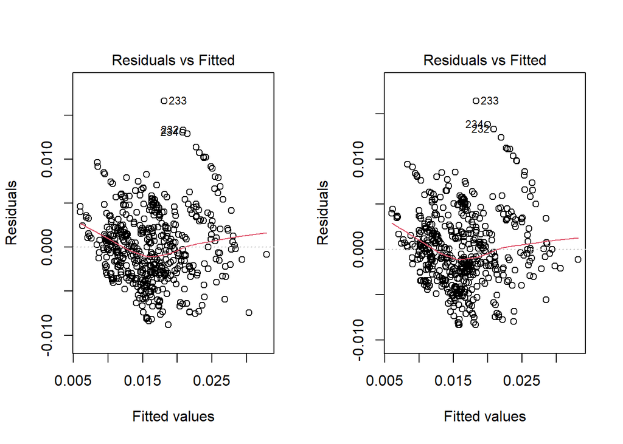

```r
par(mfrow=c(1,2))
plot(fit1,which=1)
plot(fit2,which=1)
```

**Lekha - Chapter 8 (Transformation Part)**

Importing required data:

```r
rm(list=ls())
library(corrplot)
df <- read.csv(file="volatility.csv")
head(df)
```

|  | VIX.Close | AAPL.Close | VXAPLCLS | VXAZNCLS | VXGOGCLS | GOOG.Close | AMZN.Close | GSPC.Close | Date | AAPL.Ret | AMZN.Ret | GOOG.Ret | GSPC.Ret | AAPL.Vol | AAPL.PVol | AMZN.PVol | GOOG.PVol | GSPC.PVol |
| --- | --- | --- | --- | --- | --- | --- | --- | --- | --- | --- | --- | --- | --- | --- | --- | --- | --- | --- |
| 1 | 9.77 | 43.0650 | 24.25 | 26.59 | 20.29 | 1065.00 | 1189.01 | 2695.81 | 0 | 0.0177462274 | 0.016570407 | 0.0176190745 | 0.008269079 | 0.009281281 | 0.010094766 | 0.009585190 | 0.008515679 | 0.003848145 |
| 2 | 9.15 | 43.0575 | 24.47 | 26.15 | 20.69 | 1082.48 | 1204.20 | 2713.06 | 1 | -0.0001741705 | 0.012694369 | 0.0162798873 | 0.006378433 | 0.013203660 | 0.010035844 | 0.009467315 | 0.008510240 | 0.003968167 |
| 3 | 9.22 | 43.2575 | 23.88 | 26.45 | 21.55 | 1086.40 | 1209.59 | 2723.99 | 2 | 0.0046342202 | 0.004466026 | 0.0036148134 | 0.004020543 | 0.013895430 | 0.009918126 | 0.007285792 | 0.007812724 | 0.003974761 |
| 4 | 9.22 | 43.7500 | 24.46 | 26.15 | 21.89 | 1102.23 | 1229.14 | 2743.15 | 3 | 0.0113209841 | 0.016033319 | 0.0144658823 | 0.007009146 | 0.016809831 | 0.010162405 | 0.007785569 | 0.008127326 | 0.003957652 |
| 5 | 9.52 | 43.5875 | 25.15 | 27.83 | 23.20 | 1106.94 | 1246.87 | 2747.71 | 6 | -0.0037211549 | 0.014321657 | 0.0042640162 | 0.001660964 | 0.017276625 | 0.010162417 | 0.008041353 | 0.007880169 | 0.003928786 |
| 6 | 10.08 | 43.5825 | 25.23 | 28.04 | 21.19 | 1106.26 | 1252.70 | 2751.29 | 7 | -0.0001147643 | 0.004664776 | -0.0006144325 | 0.001302083 | 0.017995092 | 0.010167934 | 0.008021084 | 0.007702502 | 0.003927635 |

```r
AAPL.PVol = df$AAPL.PVol
GOOG.PVol = df$GOOG.PVol
AMZN.PVol = df$AMZN.PVol
GSPC.PVol = df$GSPC.PVol
VIX.Close = df$VIX.Close
AAPL.Close = df$AAPL.Close
VXAPLCLS = df$VXAPLCLS
VXAZNCLS = df$VXAZNCLS
VXGOGCLS = df$VXGOGCLS
GOOG.Close = df$GOOG.Close
AMZN.Close = df$AMZN.Close
GSPC.Close = df$GSPC.Close
Date = df$Date
AAPL.Ret = df$AAPL.Ret
AMZN.Ret = df$AMZN.Ret
GOOG.Ret = df$GOOG.Ret
GSPC.Ret = df$GSPC.Ret
AAPL.Vol = df$AAPL.Vol
```

```r
library(dplyr)
```

```r
library(ggplot2)
```

We will check for higher-order terms and whether they’re necessary to add or not by centering the predictor variables for each case, and performing required tests on these centered predictor variables and Y. For each one, we considered $\alpha = 0.05$.

```r
Y = AAPL.Vol
```

Starting with:

# AAPL.Vol vs AAPL.PVol:

```r
currX = AAPL.PVol
n = length(AAPL.Vol)
Xbar = sum(AAPL.PVol)/n

#centering predictor variable

smallx = currX - Xbar

xsquare = smallx*smallx

currmod = lm(Y ~ smallx+xsquare)
summary(currmod)
```

```
##
## Call:
## lm(formula = Y ~ smallx + xsquare)
##
## Residuals:
##       Min        1Q    Median        3Q       Max
## -0.013281 -0.004299 -0.001671  0.003755  0.015198
##
## Coefficients:
##              Estimate Std. Error t value Pr(>|t|)
## (Intercept) 0.0158368  0.0003359  47.150  < 2e-16 ***
## smallx      0.3092554  0.0511319   6.048 2.87e-09 ***
## xsquare     9.5705312  5.2578866   1.820   0.0693 .
## ---
## Signif. codes:  0 '***' 0.001 '**' 0.01 '*' 0.05 '.' 0.1 ' ' 1
##
## Residual standard error: 0.005861 on 500 degrees of freedom
## Multiple R-squared:  0.1399, Adjusted R-squared:  0.1364
## F-statistic: 40.65 on 2 and 500 DF,  p-value: < 2.2e-16
```

Now plotting Y against X only:

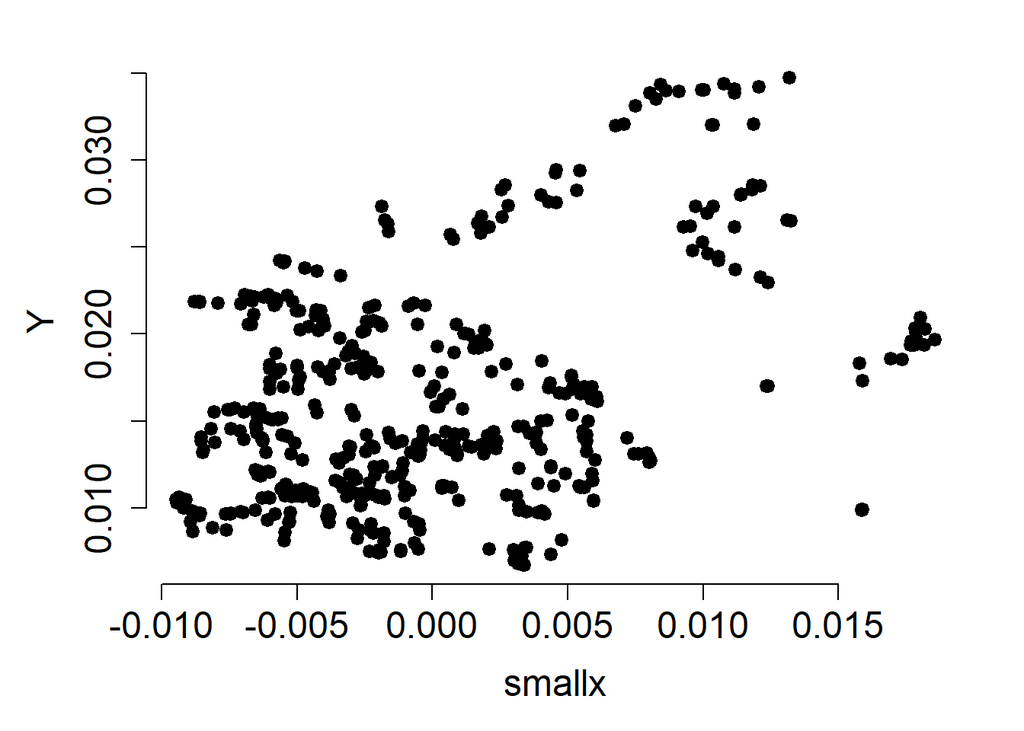

```r
par(lwd = 3, cex.axis = 1.5, cex.lab = 1.5, mar = c(5,5,2,2))
plot(Y~smallx, pch = 20, bty = "n", lwd = 5)
```

The graph doesn’t seem to be parabolic, so it doesn’t indicate interaction term at first glance.

We found from Part 2, that there is a relation between AAPL.PVol and AAPL.Vol, but now doing the same when AAPL.PVol is centered, we will test if there is any relation at all: * Null hypothesis $H_0: \beta_2 = 0$ * Alternate hypothesis $H_A: \beta_2 \neq 0$

Test statistic is $F_{obs} = \frac{MSR}{MSE} = \frac{SSR(x^2|x)/1}{SSE(x,x^2)/n-3}$

```r
curranova = anova(currmod)
curranova
```

|  | Df | Sum Sq | Mean Sq | F value | Pr(>F) |
| --- | --- | --- | --- | --- | --- |
| smallx | 1 | 0.002678621 | 0.0026786214 | 77.988425 | 1.755973e-17 |
| xsquare | 1 | 0.000113797 | 0.0001137970 | 3.313215 | 6.932261e-02 |
| Residuals | 500 | 0.017173198 | 0.0000343464 | NA | NA |

```r
dfsse = n-3
## SSR is second value in Mean Sq column of the anova table
## SSE is bottom most value in Sum Sq column
Fobs = 0.00011380 / (0.0171732/dfsse)

#or could be taken from ANOVA table
Fobs = curranova[2,4]
Fobs
```

```
## [1] 3.313215
```

Our critical value is:

```r
alpha = 0.05

Fstar = qf(1 - alpha, 1, n-3)
Fstar
```

```
## [1] 3.860124
```

Our test statistic value is less than critical value, so we conclude that we fail to reject the null hypothesis.

Hence, in the case of predictor variable AAPL.Vol, we can use linear model of order 1, and not add its square.

Now, to de-center our function, we replace x by $X - \bar{X}$. Since we anyway will not consider the quadratic term, we can just state the linear regression equation as it is for Y and X:

```r
mod = lm(Y ~ currX)
mod$coefficients
```

```
## (Intercept)       currX
##   0.0103326   0.3642590
```

$$\hat{Y} = 0.01033 + 0.3643X_1$$

# AAPL.Vol vs AMZN.PVol higher order:

```r
currX = AMZN.PVol
n = length(AAPL.Vol)
Xbar = sum(AMZN.PVol)/n

#centering predictor variable

smallx = currX - Xbar

xsquare = smallx*smallx

currmod = lm(Y ~ smallx+xsquare)
summary(currmod)
```

```
##
## Call:
## lm(formula = Y ~ smallx + xsquare)
##
## Residuals:
##        Min         1Q     Median         3Q        Max
## -0.0101734 -0.0039287 -0.0008275  0.0034527  0.0135901
##
## Coefficients:
##              Estimate Std. Error t value Pr(>|t|)
## (Intercept) 1.486e-02  3.151e-04  47.155  < 2e-16 ***
## smallx      1.970e-01  3.965e-02   4.969 9.25e-07 ***
## xsquare     1.808e+01  2.857e+00   6.330 5.46e-10 ***
## ---
## Signif. codes:  0 '***' 0.001 '**' 0.01 '*' 0.05 '.' 0.1 ' ' 1
##
## Residual standard error: 0.005162 on 500 degrees of freedom
## Multiple R-squared:  0.3328, Adjusted R-squared:  0.3301
## F-statistic: 124.7 on 2 and 500 DF,  p-value: < 2.2e-16
```

Now plotting Y against X only:

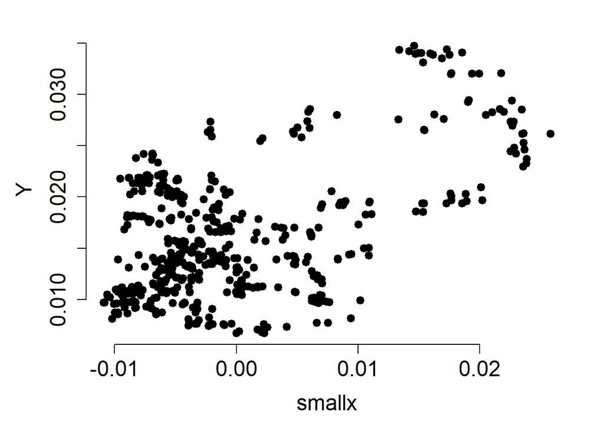

```r
par(lwd = 3, cex.axis = 1.5, cex.lab = 1.5, mar = c(5,5,2,2))
plot(Y~smallx, pch = 20, bty = "n", lwd = 5)
```

The graph doesn’t seem to be parabolic, so it doesn’t indicate interaction term at first glance.

We found from Part 2, that there is a relation between AMZN.PVol and AAPL.Vol, but now doing the same when AMZN.PVol is centered, we will test if there is any relation at all: * Null hypothesis $H_0: \beta_2 = 0$ * Alternate hypothesis $H_A: \beta_2 \neq 0$

Test statistic is $F_{obs} = \frac{MSR}{MSE} = \frac{SSR(x^2|x)/1}{SSE(x,x^2)/n-3}$

```r
curranova = anova(currmod)
curranova
```

|  | Df | Sum Sq | Mean Sq | F value | Pr(>F) |
| --- | --- | --- | --- | --- | --- |
| smallx | 1 | 0.005576515 | 5.576515e-03 | 209.30393 | 7.073453e-40 |
| xsquare | 1 | 0.001067530 | 1.067530e-03 | 40.06772 | 5.461507e-10 |
| Residuals | 500 | 0.013321572 | 2.664314e-05 | NA | NA |

```r
dfsse = n-3

## SSR is second value in Mean Sq column of the anova table
## SSE is bottom most value in Sum Sq column
Fobs = curranova[2,3] / ((curranova[3,2])/dfsse)
Fobs
```

```
## [1] 40.06772
```

```r
#or could be taken from ANOVA table
Fobs2 = curranova[2,4]
Fobs2
```

```
## [1] 40.06772
```

Our critical value is:

```r
alpha = 0.05

Fstar = qf(1 - alpha, 1, n-3)
Fstar
```

```
## [1] 3.860124
```

Our test statistic value is greater than critical value, so we conclude that we reject the null hypothesis.

Hence, the quadratic term of AMZN.PVol is significant.

# AAPL.Vol vs GOOG.PVol higher order:

```r
currX = GOOG.PVol
n = length(AAPL.Vol)
Xbar = sum(GOOG.PVol)/n

#centering predictor variable

smallx = currX - Xbar

xsquare = smallx*smallx

currmod = lm(Y ~ smallx+xsquare)
summary(currmod)
```

```
##
## Call:
## lm(formula = Y ~ smallx + xsquare)
##
## Residuals:
##       Min        1Q    Median        3Q       Max
## -0.013832 -0.004297 -0.000841  0.003069  0.018441
##
## Coefficients:
##              Estimate Std. Error t value Pr(>|t|)
## (Intercept) 1.434e-02  3.818e-04  37.554  < 2e-16 ***
## smallx      3.085e-01  4.739e-02   6.508 1.85e-10 ***
## xsquare     5.792e+01  8.892e+00   6.513 1.79e-10 ***
## ---
## Signif. codes:  0 '***' 0.001 '**' 0.01 '*' 0.05 '.' 0.1 ' ' 1
##
## Residual standard error: 0.005596 on 500 degrees of freedom
## Multiple R-squared:  0.2157, Adjusted R-squared:  0.2126
## F-statistic: 68.76 on 2 and 500 DF,  p-value: < 2.2e-16
```

Now plotting Y against X only:

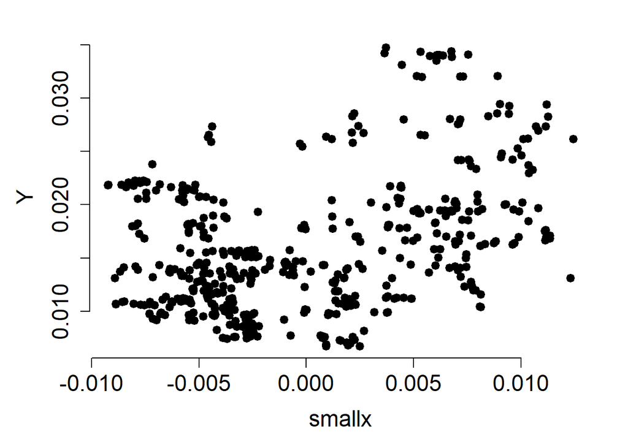

```r
par(lwd = 3, cex.axis = 1.5, cex.lab = 1.5, mar = c(5,5,2,2))
plot(Y~smallx, pch = 20, bty = "n", lwd = 5)
```

The graph doesn’t seem to be parabolic, so it doesn’t indicate interaction term at first glance.

We found from Part 2, that there is a relation between GOOG.PVol and AAPL.Vol, but now doing the same when GOOG.PVol is centered, we will test if there is any relation at all: * Null hypothesis $H_0: \beta_2 = 0$ * Alternate hypothesis $H_A: \beta_2 \neq 0$

Test statistic is $F_{obs} = \frac{MSR}{MSE} = \frac{SSR(x^2|x)/1}{SSE(x,x^2)/n-3}$

```r
curranova = anova(currmod)
curranova
```

|  | Df | Sum Sq | Mean Sq | F value | Pr(>F) |
| --- | --- | --- | --- | --- | --- |
| smallx | 1 | 0.002978359 | 2.978359e-03 | 95.10249 | 1.097896e-20 |
| xsquare | 1 | 0.001328578 | 1.328578e-03 | 42.42305 | 1.794379e-10 |
| Residuals | 500 | 0.015658680 | 3.131736e-05 | NA | NA |

```r
dfsse = n-3

## SSR is second value in Mean Sq column of the anova table
## SSE is bottom most value in Sum Sq column
Fobs = curranova[2,3] / ((curranova[3,2])/dfsse)
Fobs
```

```
## [1] 42.42305
```

```r
#or could be taken from ANOVA table
Fobs2 = curranova[2,4]
Fobs2
```

```
## [1] 42.42305
```

Our critical value is:

```r
alpha = 0.05

Fstar = qf(1 - alpha, 1, n-3)
Fstar
```

```
## [1] 3.860124
```

Our test statistic value is greater than critical value, so we conclude that we reject the null hypothesis.

Hence, the quadratic term $X^2$ in the case of GOOG.PVol is significant.

# AAPL.Vol vs GSPC.PVol higher order:

```r
currX = GSPC.PVol
n = length(AAPL.Vol)
Xbar = sum(GSPC.PVol)/n

#centering predictor variable

smallx = currX - Xbar

xsquare = smallx*smallx

currmod = lm(Y ~ smallx+xsquare)
summary(currmod)
```

```
##
## Call:
## lm(formula = Y ~ smallx + xsquare)
##
## Residuals:
##       Min        1Q    Median        3Q       Max
## -0.010839 -0.004529 -0.001325  0.003793  0.017576
##
## Coefficients:
##              Estimate Std. Error t value Pr(>|t|)
## (Intercept) 1.523e-02  3.766e-04  40.434  < 2e-16 ***
## smallx      3.787e-01  8.104e-02   4.673 3.82e-06 ***
## xsquare     5.719e+01  1.580e+01   3.619 0.000326 ***
## ---
## Signif. codes:  0 '***' 0.001 '**' 0.01 '*' 0.05 '.' 0.1 ' ' 1
##
## Residual standard error: 0.00578 on 500 degrees of freedom
## Multiple R-squared:  0.1633, Adjusted R-squared:  0.1599
## F-statistic: 48.79 on 2 and 500 DF,  p-value: < 2.2e-16
```

Now plotting Y against X only:

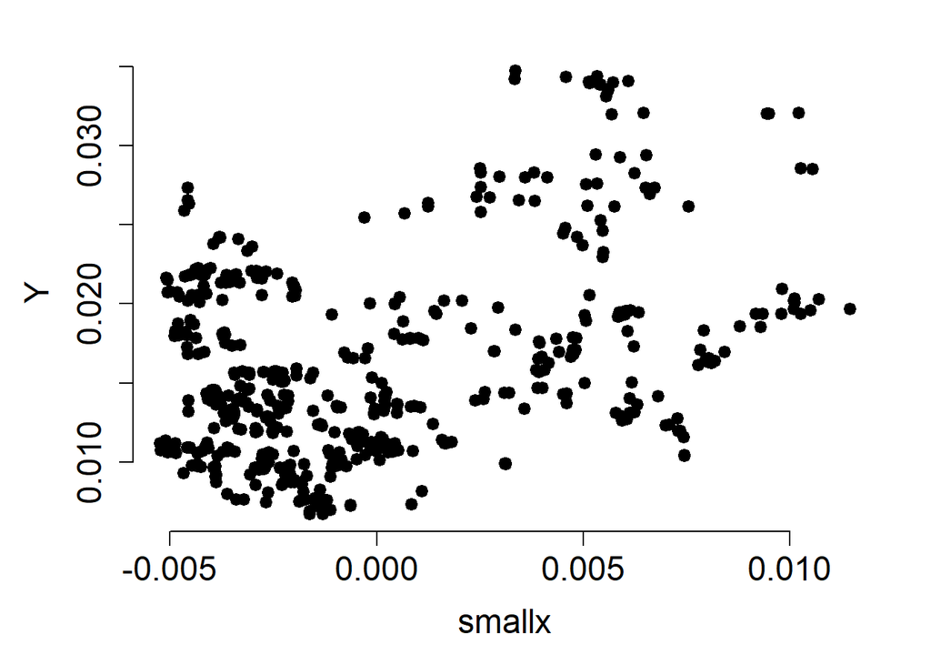

```r
par(lwd = 3, cex.axis = 1.5, cex.lab = 1.5, mar = c(5,5,2,2))
plot(Y~smallx, pch = 20, bty = "n", lwd = 5)
```

The graph doesn’t seem to be parabolic, so it doesn’t indicate interaction term at first glance.

We found from Part 2, that there is a relation between GSPC.PVol and AAPL.Vol, but now doing the same when GSPC.PVol is centered, we will test if there is any relation at all: * Null hypothesis $H_0: \beta_2 = 0$ * Alternate hypothesis $H_A: \beta_2 \neq 0$

Test statistic is $F_{obs} = \frac{MSR}{MSE} = \frac{SSR(x^2|x)/1}{SSE(x,x^2)/n-3}$

```r
curranova = anova(currmod)
curranova
```

|  | Df | Sum Sq | Mean Sq | F value | Pr(>F) |
| --- | --- | --- | --- | --- | --- |
| smallx | 1 | 0.0028225887 | 2.822589e-03 | 84.48061 | 1.040498e-18 |
| xsquare | 1 | 0.0004374854 | 4.374854e-04 | 13.09402 | 3.263755e-04 |
| Residuals | 500 | 0.0167055424 | 3.341108e-05 | NA | NA |

```r
dfsse = n-3

## SSR is second value in Mean Sq column of the anova table
## SSE is bottom most value in Sum Sq column
Fobs = curranova[2,3] / ((curranova[3,2])/dfsse)
Fobs
```

```
## [1] 13.09402
```

```r
#or could be taken from ANOVA table
Fobs2 = curranova[2,4]
Fobs2
```

```
## [1] 13.09402
```

Our critical value is:

```r
alpha = 0.05

Fstar = qf(1 - alpha, 1, n-3)
Fstar
```

```
## [1] 3.860124
```

Our test statistic value is greater than critical value, so we conclude that we reject the null hypothesis.

Hence, the quadratic term for GSPC.PVol is significant.

# AAPL.Vol vs AAPL.Close higher order:

```r
currX = AAPL.Close
n = length(AAPL.Vol)
Xbar = sum(AAPL.Close)/n

#centering predictor variable

smallx = currX - Xbar

xsquare = smallx*smallx

currmod = lm(Y ~ smallx+xsquare)
summary(currmod)
```

```
##
## Call:
## lm(formula = Y ~ smallx + xsquare)
##
## Residuals:
##       Min        1Q    Median        3Q       Max
## -0.010134 -0.003786 -0.001354  0.003274  0.017791
##
## Coefficients:
##               Estimate Std. Error t value Pr(>|t|)
## (Intercept)  1.623e-02  3.412e-04  47.563  < 2e-16 ***
## smallx      -2.030e-04  4.408e-05  -4.605 5.23e-06 ***
## xsquare     -1.232e-07  3.637e-06  -0.034    0.973
## ---
## Signif. codes:  0 '***' 0.001 '**' 0.01 '*' 0.05 '.' 0.1 ' ' 1
##
## Residual standard error: 0.006131 on 500 degrees of freedom
## Multiple R-squared:  0.05877,    Adjusted R-squared:  0.055
## F-statistic: 15.61 on 2 and 500 DF,  p-value: 2.656e-07
```

Now plotting Y against X only:

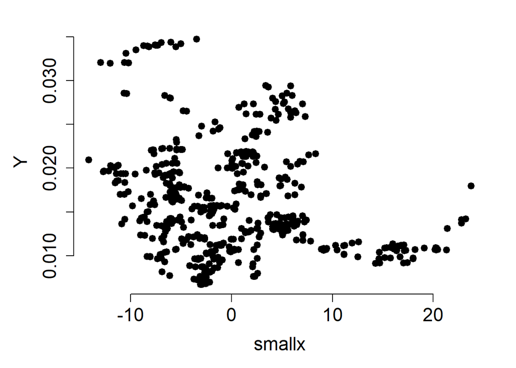

```r
par(lwd = 3, cex.axis = 1.5, cex.lab = 1.5, mar = c(5,5,2,2))
plot(Y~smallx, pch = 20, bty = "n", lwd = 5)
```

The graph doesn’t seem to be parabolic, so it doesn’t indicate interaction term at first glance.

We found from Part 2, that there is a relation between AAPL.Close and AAPL.Vol, but now doing the same when AAPL.Close is centered, we will test if there is any relation at all: * Null hypothesis $H_0: \beta_2 = 0$ * Alternate hypothesis $H_A: \beta_2 \neq 0$

Test statistic is $F_{obs} = \frac{MSR}{MSE} = \frac{SSR(x^2|x)/1}{SSE(x,x^2)/n-3}$

```r
curranova = anova(currmod)
curranova
```

|  | Df | Sum Sq | Mean Sq | F value | Pr(>F) |
| --- | --- | --- | --- | --- | --- |
| smallx | 1 | 1.173300e-03 | 1.173300e-03 | 31.217623603 | 3.794538e-08 |
| xsquare | 1 | 4.312295e-08 | 4.312295e-08 | 0.001147359 | 9.729922e-01 |
| Residuals | 500 | 1.879227e-02 | 3.758455e-05 | NA | NA |

```r
dfsse = n-3

## SSR is second value in Mean Sq column of the anova table
## SSE is bottom most value in Sum Sq column
Fobs = curranova[2,3] / ((curranova[3,2])/dfsse)
Fobs
```

```
## [1] 0.001147359
```

```r
#or could be taken from ANOVA table
Fobs2 = curranova[2,4]
Fobs2
```

```
## [1] 0.001147359
```

Our critical value is:

```r
alpha = 0.05

Fstar = qf(1 - alpha, 1, n-3)
Fstar
```

```
## [1] 3.860124
```

Our test statistic value is less than critical value, so we conclude that we fail to reject the null hypothesis.

Hence, in the case of AAPL.Close, its quadratic term isn’t significant.

# AAPL.Vol vs AMZN.Close higher order:

```r
currX = AMZN.Close
n = length(AAPL.Vol)
Xbar = sum(AMZN.Close)/n

#centering predictor variable

smallx = currX - Xbar

xsquare = smallx*smallx

currmod = lm(Y ~ smallx+xsquare)
summary(currmod)
```

```
##
## Call:
## lm(formula = Y ~ smallx + xsquare)
##
## Residuals:
##       Min        1Q    Median        3Q       Max
## -0.014740 -0.004550 -0.001449  0.003090  0.019341
##
## Coefficients:
##               Estimate Std. Error t value Pr(>|t|)
## (Intercept)  1.539e-02  3.507e-04  43.901  < 2e-16 ***
## smallx      -1.827e-06  1.758e-06  -1.039 0.299267
## xsquare      2.764e-08  7.256e-09   3.809 0.000157 ***
## ---
## Signif. codes:  0 '***' 0.001 '**' 0.01 '*' 0.05 '.' 0.1 ' ' 1
##
## Residual standard error: 0.006178 on 500 degrees of freedom
## Multiple R-squared:  0.04409,    Adjusted R-squared:  0.04026
## F-statistic: 11.53 on 2 and 500 DF,  p-value: 1.272e-05
```

Now plotting Y against X only:

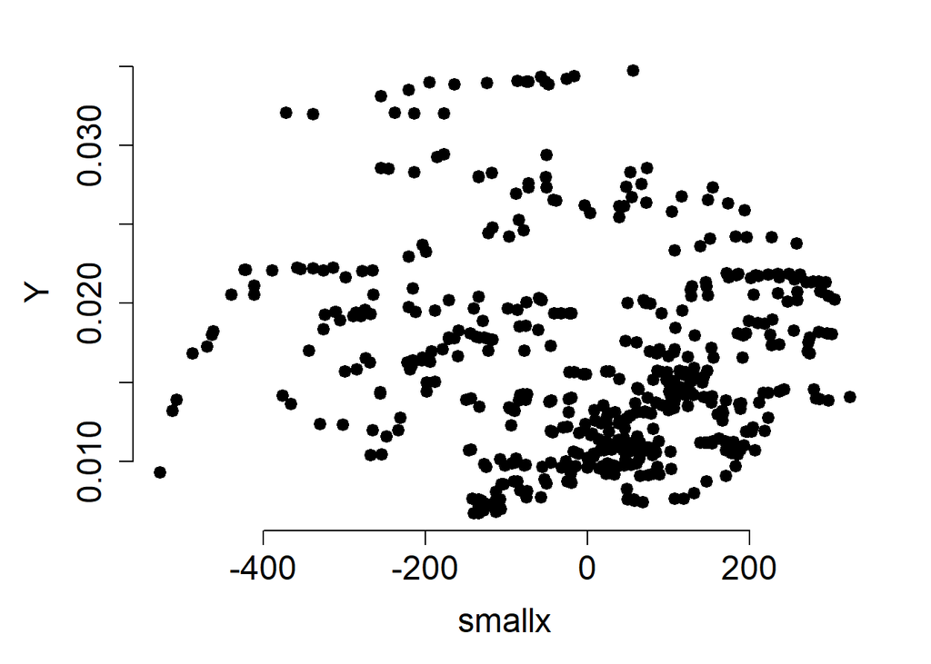

```r
par(lwd = 3, cex.axis = 1.5, cex.lab = 1.5, mar = c(5,5,2,2))
plot(Y~smallx, pch = 20, bty = "n", lwd = 5)
```

The graph doesn’t seem to be parabolic, so it doesn’t indicate interaction term at first glance.

We found from Part 2, that there is a relation between AMZN.Close and AAPL.Vol, but now doing the same when AMZN.Close is centered, we will test if there is any relation at all: * Null hypothesis $H_0: \beta_2 = 0$ * Alternate hypothesis $H_A: \beta_2 \neq 0$

Test statistic is $F_{obs} = \frac{MSR}{MSE} = \frac{SSR(x^2|x)/1}{SSE(x,x^2)/n-3}$

```r
curranova = anova(currmod)
curranova
```

|  | Df | Sum Sq | Mean Sq | F value | Pr(>F) |
| --- | --- | --- | --- | --- | --- |
| smallx | 1 | 0.0003263444 | 3.263444e-04 | 8.549587 | 0.0036127906 |
| xsquare | 1 | 0.0005538859 | 5.538859e-04 | 14.510733 | 0.0001567038 |
| Residuals | 500 | 0.0190853863 | 3.817077e-05 | NA | NA |

```r
dfsse = n-3

## SSR is second value in Mean Sq column of the anova table
## SSE is bottom most value in Sum Sq column
Fobs = curranova[2,3] / ((curranova[3,2])/dfsse)
Fobs
```

```
## [1] 14.51073
```

```r
#or could be taken from ANOVA table
Fobs2 = curranova[2,4]
Fobs2
```

```
## [1] 14.51073
```

Our critical value is:

```r
alpha = 0.05

Fstar = qf(1 - alpha, 1, n-3)
Fstar
```

```
## [1] 3.860124
```

Hence, the quadratic term $X^2$ for AMZN.Close is significant

# AAPL.Vol vs GOOG.Close higher order:

```r
currX = GOOG.Close
n = length(AAPL.Vol)
Xbar = sum(GOOG.Close)/n

#centering predictor variable

smallx = currX - Xbar

xsquare = smallx*smallx

currmod = lm(Y ~ smallx+xsquare)
summary(currmod)
```

```
##
## Call:
## lm(formula = Y ~ smallx + xsquare)
##
## Residuals:
##        Min         1Q     Median         3Q        Max
## -0.0121719 -0.0033757 -0.0008007  0.0032752  0.0174526
##
## Coefficients:
##               Estimate Std. Error t value Pr(>|t|)
## (Intercept)  1.583e-02  3.388e-04  46.705   <2e-16 ***
## smallx      -2.995e-05  3.292e-06  -9.098   <2e-16 ***
## xsquare      5.653e-08  3.092e-08   1.828   0.0681 .
## ---
## Signif. codes:  0 '***' 0.001 '**' 0.01 '*' 0.05 '.' 0.1 ' ' 1
##
## Residual standard error: 0.005846 on 500 degrees of freedom
## Multiple R-squared:  0.1441, Adjusted R-squared:  0.1406
## F-statistic: 42.07 on 2 and 500 DF,  p-value: < 2.2e-16
```

Now plotting Y against X only:

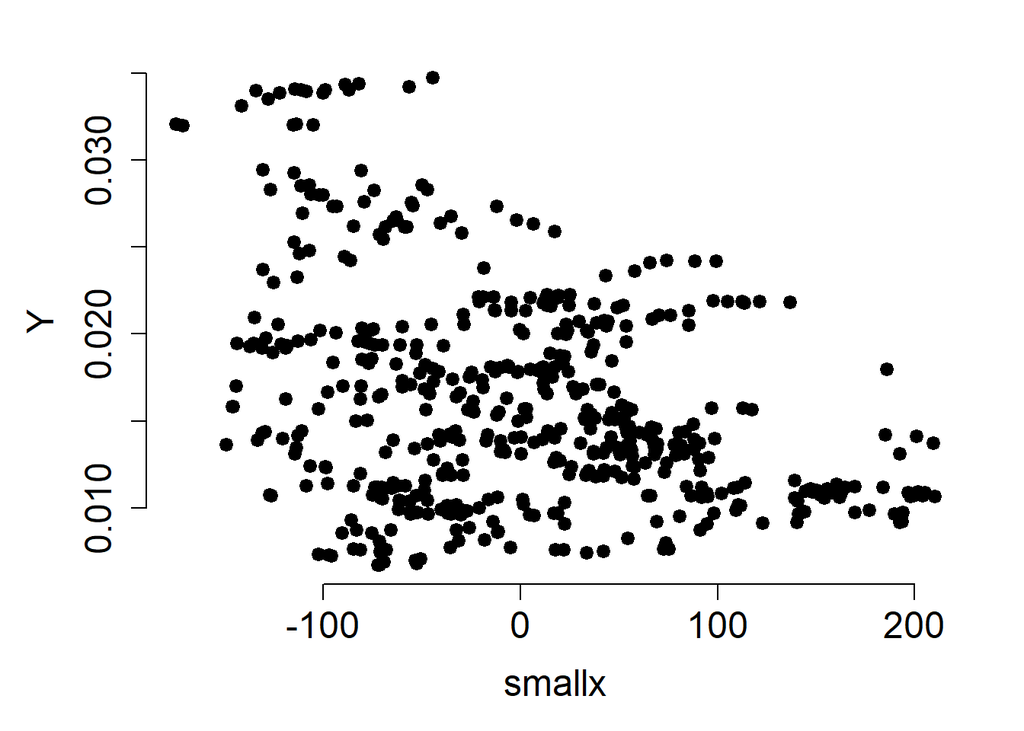

```r
par(lwd = 3, cex.axis = 1.5, cex.lab = 1.5, mar = c(5,5,2,2))
plot(Y~smallx, pch = 20, bty = "n", lwd = 5)
```

The graph doesn’t seem to be parabolic, so it doesn’t indicate interaction term at first glance.

We found from Part 2, that there is a relation between GOOG.Close and AAPL.Vol, but now doing the same when GOOG.Close is centered, we will test if there is any relation at all: * Null hypothesis $H_0: \beta_2 = 0$ * Alternate hypothesis $H_A: \beta_2 \neq 0$

Test statistic is $F_{obs} = \frac{MSR}{MSE} = \frac{SSR(x^2|x)/1}{SSE(x,x^2)/n-3}$

```r
curranova = anova(currmod)
curranova
```

|  | Df | Sum Sq | Mean Sq | F value | Pr(>F) |
| --- | --- | --- | --- | --- | --- |
| smallx | 1 | 0.0027618320 | 2.761832e-03 | 80.804853 | 5.131900e-18 |
| xsquare | 1 | 0.0001142666 | 1.142666e-04 | 3.343177 | 6.807978e-02 |
| Residuals | 500 | 0.0170895180 | 3.417904e-05 | NA | NA |

```r
dfsse = n-3

## SSR is second value in Mean Sq column of the anova table
## SSE is bottom most value in Sum Sq column
Fobs = curranova[2,3] / ((curranova[3,2])/dfsse)
Fobs
```

```
## [1] 3.343177
```

```r
#or could be taken from ANOVA table
Fobs2 = curranova[2,4]
Fobs2
```

```
## [1] 3.343177
```

Our critical value is:

```r
alpha = 0.05

Fstar = qf(1 - alpha, 1, n-3)
Fstar
```

```
## [1] 3.860124
```

Our test statistic value is less than critical value, so we conclude that we fail to reject the null hypothesis.

Hence, the quadratic term $X^2$ for GOOG.Close is not significant.

# AAPL.Vol vs GSPC.Close higher order:

```r
currX = GSPC.Close
n = length(AAPL.Vol)
Xbar = sum(GSPC.Close)/n

#centering predictor variable

smallx = currX - Xbar

xsquare = smallx*smallx

currmod = lm(Y ~ smallx+xsquare)
summary(currmod)
```

```
##
## Call:
## lm(formula = Y ~ smallx + xsquare)
##
## Residuals:
##        Min         1Q     Median         3Q        Max
## -0.0115261 -0.0036555 -0.0009736  0.0040549  0.0184977
##
## Coefficients:
##               Estimate Std. Error t value Pr(>|t|)
## (Intercept)  1.558e-02  3.199e-04  48.713  < 2e-16 ***
## smallx      -1.507e-05  1.741e-06  -8.654  < 2e-16 ***
## xsquare      2.731e-08  7.880e-09   3.465 0.000575 ***
## ---
## Signif. codes:  0 '***' 0.001 '**' 0.01 '*' 0.05 '.' 0.1 ' ' 1
##
## Residual standard error: 0.005873 on 500 degrees of freedom
## Multiple R-squared:  0.1362, Adjusted R-squared:  0.1328
## F-statistic: 39.43 on 2 and 500 DF,  p-value: < 2.2e-16
```

Now plotting Y against X only:

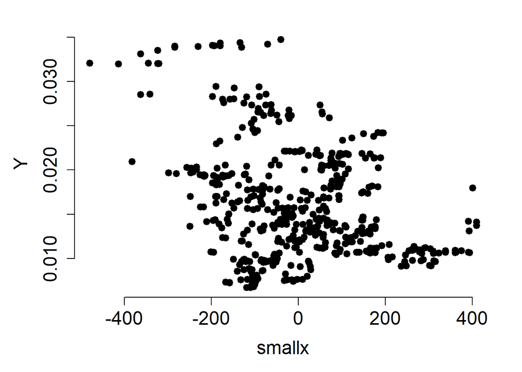

```r
par(lwd = 3, cex.axis = 1.5, cex.lab = 1.5, mar = c(5,5,2,2))
plot(Y~smallx, pch = 20, bty = "n", lwd = 5)
```

The graph doesn’t seem to be parabolic, so it doesn’t indicate interaction term at first glance.

We found from Part 2, that there is a relation between GSPC.Close and AAPL.Vol, but now doing the same when GSPC.Close is centered, we will test if there is any relation at all: * Null hypothesis $H_0: \beta_2 = 0$ * Alternate hypothesis $H_A: \beta_2 \neq 0$

Test statistic is $F_{obs} = \frac{MSR}{MSE} = \frac{SSR(x^2|x)/1}{SSE(x,x^2)/n-3}$

```r
curranova = anova(currmod)
curranova
```

|  | Df | Sum Sq | Mean Sq | F value | Pr(>F) |
| --- | --- | --- | --- | --- | --- |
| smallx | 1 | 0.0023059888 | 2.305989e-03 | 66.85798 | 2.421518e-15 |
| xsquare | 1 | 0.0004142005 | 4.142005e-04 | 12.00900 | 5.750023e-04 |
| Residuals | 500 | 0.0172454272 | 3.449085e-05 | NA | NA |

```r
dfsse = n-3

## SSR is second value in Mean Sq column of the anova table
## SSE is bottom most value in Sum Sq column
Fobs = curranova[2,3] / ((curranova[3,2])/dfsse)
Fobs
```

```
## [1] 12.009
```

```r
#or could be taken from ANOVA table
Fobs2 = curranova[2,4]
Fobs2
```

```
## [1] 12.009
```

Our critical value is:

```r
alpha = 0.05

Fstar = qf(1 - alpha, 1, n-3)
Fstar
```

```
## [1] 3.860124
```

Our test statistic value is greater than critical value, so we conclude that we reject the null hypothesis.

Hence, the quadratic term $X^2$ for GSPC.Close is significant.

# AAPL.Vol vs VXAPLCLS higher order:

```r
currX = VXAPLCLS
n = length(AAPL.Vol)
Xbar = sum(VXAPLCLS)/n

#centering predictor variable

smallx = currX - Xbar

xsquare = smallx*smallx

currmod = lm(Y ~ smallx+xsquare)
summary(currmod)
```

```
##
## Call:
## lm(formula = Y ~ smallx + xsquare)
##
## Residuals:
##        Min         1Q     Median         3Q        Max
## -0.0114239 -0.0036964 -0.0007178  0.0033604  0.0190810
##
## Coefficients:
##              Estimate Std. Error t value Pr(>|t|)
## (Intercept) 1.605e-02  2.497e-04  64.259   <2e-16 ***
## smallx      6.943e-04  4.028e-05  17.236   <2e-16 ***
## xsquare     5.135e-06  3.955e-06   1.298    0.195
## ---
## Signif. codes:  0 '***' 0.001 '**' 0.01 '*' 0.05 '.' 0.1 ' ' 1
##
## Residual standard error: 0.004734 on 500 degrees of freedom
## Multiple R-squared:  0.4389, Adjusted R-squared:  0.4366
## F-statistic: 195.5 on 2 and 500 DF,  p-value: < 2.2e-16
```

Now plotting Y against X only:

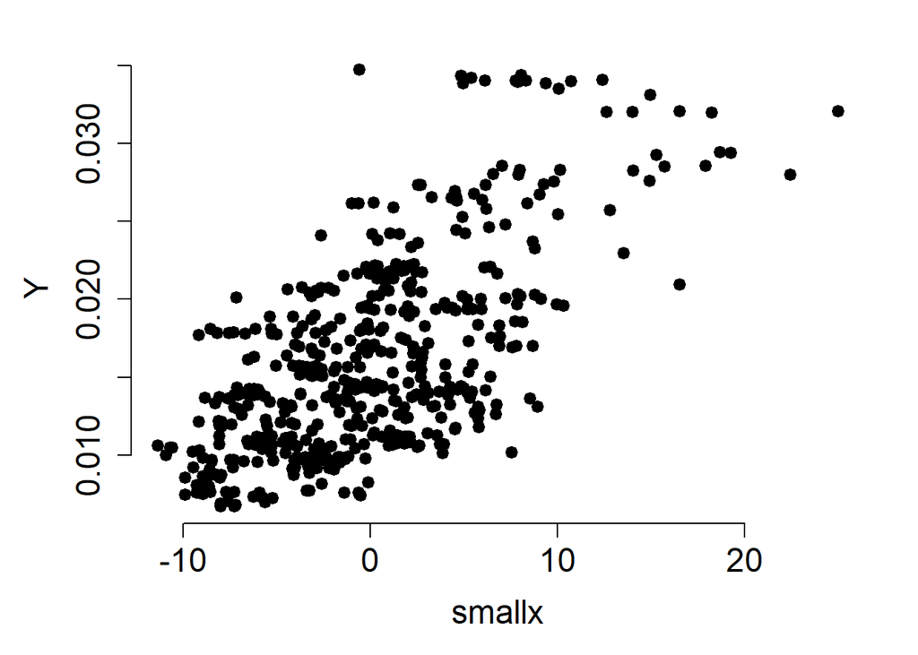

```r
par(lwd = 3, cex.axis = 1.5, cex.lab = 1.5, mar = c(5,5,2,2))
plot(Y~smallx, pch = 20, bty = "n", lwd = 5)
```

The graph doesn’t seem to be parabolic, so it doesn’t indicate interaction term at first glance.

We found from Part 2, that there is a relation between VXAPLCLS and AAPL.Vol, but now doing the same when VXAPLCLS is centered, we will test if there is any relation at all: * Null hypothesis $H_0: \beta_2 = 0$ * Alternate hypothesis $H_A: \beta_2 \neq 0$

Test statistic is $F_{obs} = \frac{MSR}{MSE} = \frac{SSR(x^2|x)/1}{SSE(x,x^2)/n-3}$

```r
curranova = anova(currmod)
curranova
```

|  | Df | Sum Sq | Mean Sq | F value | Pr(>F) |
| --- | --- | --- | --- | --- | --- |
| smallx | 1 | 8.724742e-03 | 8.724742e-03 | 389.389237 | 1.584972e-64 |
| xsquare | 1 | 3.776409e-05 | 3.776409e-05 | 1.685429 | 1.948031e-01 |
| Residuals | 500 | 1.120311e-02 | 2.240622e-05 | NA | NA |

```r
dfsse = n-3

## SSR is second value in Mean Sq column of the anova table
## SSE is bottom most value in Sum Sq column
Fobs = curranova[2,3] / ((curranova[3,2])/dfsse)
Fobs
```

```
## [1] 1.685429
```

```r
#or could be taken from ANOVA table
Fobs2 = curranova[2,4]
Fobs2
```

```
## [1] 1.685429
```

Our critical value is:

```r
alpha = 0.05

Fstar = qf(1 - alpha, 1, n-3)
Fstar
```

```
## [1] 3.860124
```

Our test statistic value is less than critical value, so we conclude that we fail to reject the null hypothesis.

Hence, the quadratic term $X^2$ for VXAPLCLS is not significant.

# AAPL.Vol vs VXAZNCLS higher order:

```r
currX = VXAZNCLS
n = length(AAPL.Vol)
Xbar = sum(VXAZNCLS)/n

#centering predictor variable

smallx = currX - Xbar

xsquare = smallx*smallx

currmod = lm(Y ~ smallx+xsquare)
summary(currmod)
```

```
##
## Call:
## lm(formula = Y ~ smallx + xsquare)
##
## Residuals:
##        Min         1Q     Median         3Q        Max
## -0.0110639 -0.0030523 -0.0003204  0.0026780  0.0173869
##
## Coefficients:
##              Estimate Std. Error t value Pr(>|t|)
## (Intercept) 1.594e-02  2.630e-04  60.616   <2e-16 ***
## smallx      5.234e-04  3.052e-05  17.152   <2e-16 ***
## xsquare     4.367e-06  2.659e-06   1.643    0.101
## ---
## Signif. codes:  0 '***' 0.001 '**' 0.01 '*' 0.05 '.' 0.1 ' ' 1
##
## Residual standard error: 0.004483 on 500 degrees of freedom
## Multiple R-squared:  0.4968, Adjusted R-squared:  0.4948
## F-statistic: 246.8 on 2 and 500 DF,  p-value: < 2.2e-16
```

Now plotting Y against X only:

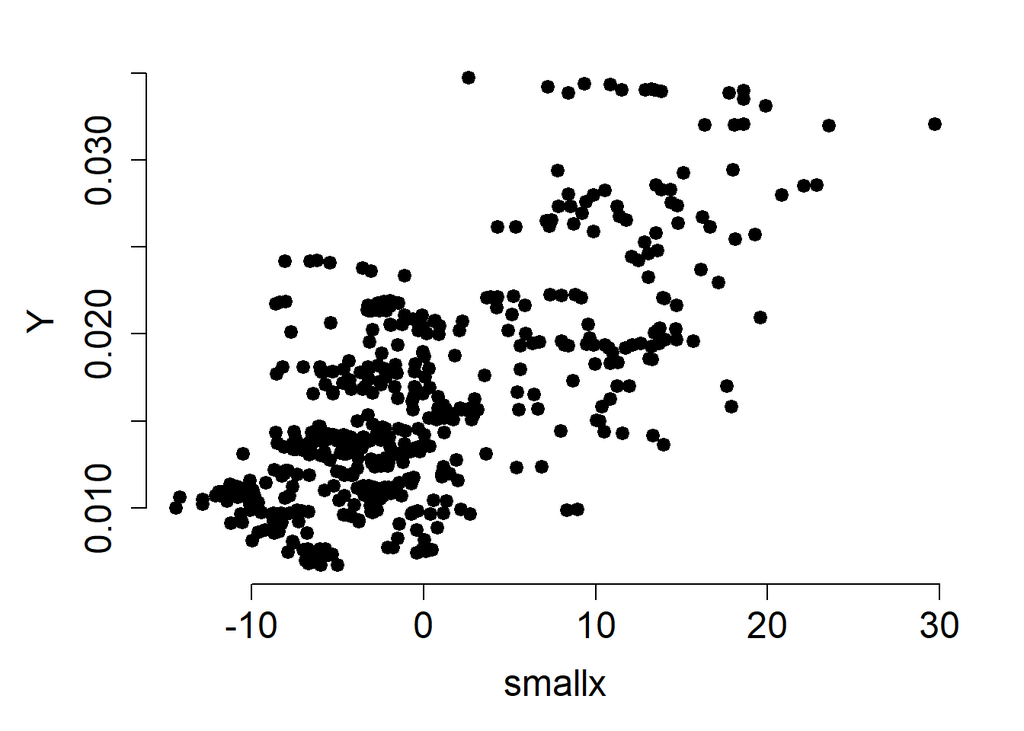

```r
par(lwd = 3, cex.axis = 1.5, cex.lab = 1.5, mar = c(5,5,2,2))
plot(Y~smallx, pch = 20, bty = "n", lwd = 5)
```

The graph doesn’t seem to be parabolic, so it doesn’t indicate interaction term at first glance.

We found from Part 2, that there is a relation between VXAZNCLS and AAPL.Vol, but now doing the same when VXAZNCLS is centered, we will test if there is any relation at all: * Null hypothesis $H_0: \beta_2 = 0$ * Alternate hypothesis $H_A: \beta_2 \neq 0$

Test statistic is $F_{obs} = \frac{MSR}{MSE} = \frac{SSR(x^2|x)/1}{SSE(x,x^2)/n-3}$

```r
curranova = anova(currmod)
curranova
```

|  | Df | Sum Sq | Mean Sq | F value | Pr(>F) |
| --- | --- | --- | --- | --- | --- |
| smallx | 1 | 9.864684e-03 | 9.864684e-03 | 490.940914 | 2.719140e-76 |
| xsquare | 1 | 5.422144e-05 | 5.422144e-05 | 2.698467 | 1.010735e-01 |
| Residuals | 500 | 1.004671e-02 | 2.009342e-05 | NA | NA |

```r
dfsse = n-3

## SSR is second value in Mean Sq column of the anova table
## SSE is bottom most value in Sum Sq column
Fobs = curranova[2,3] / ((curranova[3,2])/dfsse)
Fobs
```

```
## [1] 2.698467
```

```r
#or could be taken from ANOVA table
Fobs2 = curranova[2,4]
Fobs2
```

```
## [1] 2.698467
```

Our critical value is:

```r
alpha = 0.05

Fstar = qf(1 - alpha, 1, n-3)
Fstar
```

```
## [1] 3.860124
```

Our test statistic value is less than critical value, so we conclude that we fail to reject the null hypothesis.

Hence, the quadratic term $X^2$ for VXAZNCLS is not significant.

# AAPL.Vol vs VXGOGCLS higher order:

```r
currX = VXGOGCLS
n = length(AAPL.Vol)
Xbar = sum(VXGOGCLS)/n

#centering predictor variable

smallx = currX - Xbar

xsquare = smallx*smallx

currmod = lm(Y ~ smallx+xsquare)
summary(currmod)
```

```
##
## Call:
## lm(formula = Y ~ smallx + xsquare)
##
## Residuals:
##        Min         1Q     Median         3Q        Max
## -0.0116470 -0.0032753 -0.0002388  0.0029779  0.0176801
##
## Coefficients:
##              Estimate Std. Error t value Pr(>|t|)
## (Intercept) 1.587e-02  2.701e-04  58.739   <2e-16 ***
## smallx      7.340e-04  4.358e-05  16.844   <2e-16 ***
## xsquare     1.202e-05  5.829e-06   2.062   0.0397 *
## ---
## Signif. codes:  0 '***' 0.001 '**' 0.01 '*' 0.05 '.' 0.1 ' ' 1
##
## Residual standard error: 0.004682 on 500 degrees of freedom
## Multiple R-squared:  0.4511, Adjusted R-squared:  0.4489
## F-statistic: 205.5 on 2 and 500 DF,  p-value: < 2.2e-16
```

Now plotting Y against X only:

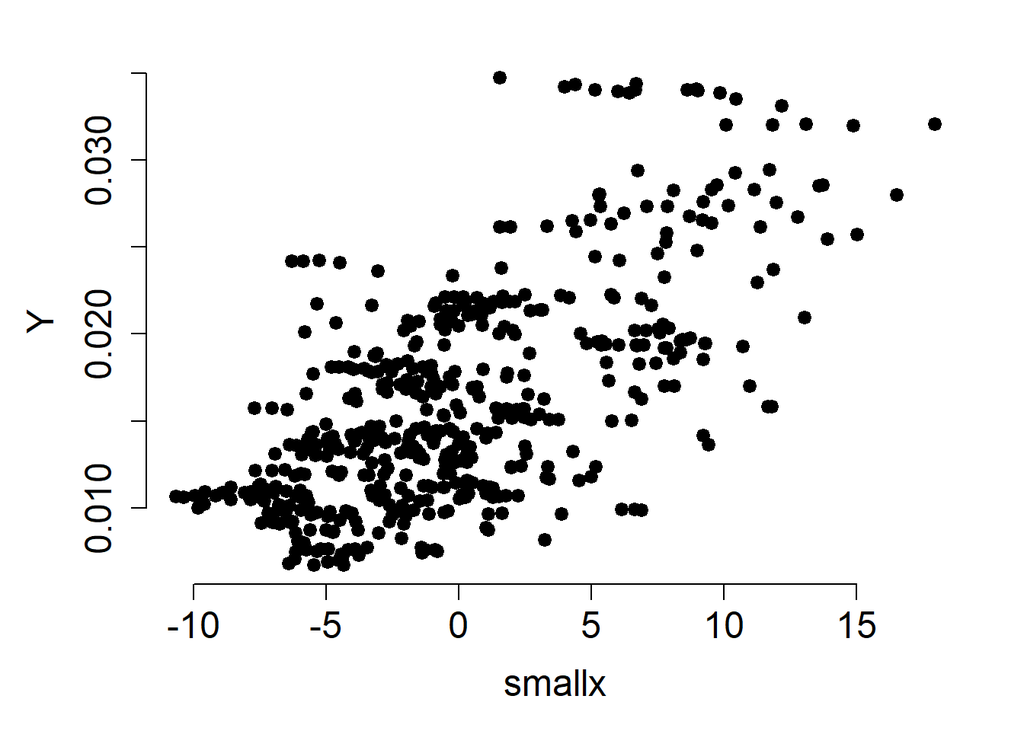

```r
par(lwd = 3, cex.axis = 1.5, cex.lab = 1.5, mar = c(5,5,2,2))
plot(Y~smallx, pch = 20, bty = "n", lwd = 5)
```

The graph doesn’t seem to be parabolic, so it doesn’t indicate interaction term at first glance.

We found from Part 2, that there is a relation between VXGOGCLS and AAPL.Vol, but now doing the same when VXGOGCLS is centered, we will test if there is any relation at all: * Null hypothesis $H_0: \beta_2 = 0$ * Alternate hypothesis $H_A: \beta_2 \neq 0$

Test statistic is $F_{obs} = \frac{MSR}{MSE} = \frac{SSR(x^2|x)/1}{SSE(x,x^2)/n-3}$

```r
curranova = anova(currmod)
curranova
```

|  | Df | Sum Sq | Mean Sq | F value | Pr(>F) |
| --- | --- | --- | --- | --- | --- |
| smallx | 1 | 8.913699e-03 | 8.913699e-03 | 406.69390 | 1.266500e-66 |
| xsquare | 1 | 9.318605e-05 | 9.318605e-05 | 4.25168 | 3.972768e-02 |
| Residuals | 500 | 1.095873e-02 | 2.191746e-05 | NA | NA |

```r
dfsse = n-3

## SSR is second value in Mean Sq column of the anova table
## SSE is bottom most value in Sum Sq column
Fobs = curranova[2,3] / ((curranova[3,2])/dfsse)
Fobs
```

```
## [1] 4.25168
```

```r
#or could be taken from ANOVA table
Fobs2 = curranova[2,4]
Fobs2
```

```
## [1] 4.25168
```

Our critical value is:

```r
alpha = 0.05

Fstar = qf(1 - alpha, 1, n-3)
Fstar
```

```
## [1] 3.860124
```

Hence, the quadratic term $X^2$ for VXGOGCLS is significant.

# AAPL.Vol vs VIX.Close higher order:

```r
currX = VIX.Close
n = length(AAPL.Vol)
Xbar = sum(VIX.Close)/n

#centering predictor variable

smallx = currX - Xbar

xsquare = smallx*smallx

currmod = lm(Y ~ smallx+xsquare)
summary(currmod)
```

```
##
## Call:
## lm(formula = Y ~ smallx + xsquare)
##
## Residuals:
##       Min        1Q    Median        3Q       Max
## -0.015370 -0.004054 -0.000990  0.003382  0.018212
##
## Coefficients:
##              Estimate Std. Error t value Pr(>|t|)
## (Intercept) 1.620e-02  2.857e-04  56.717   <2e-16 ***
## smallx      7.153e-04  8.025e-05   8.913   <2e-16 ***
## xsquare     1.095e-06  8.401e-06   0.130    0.896
## ---
## Signif. codes:  0 '***' 0.001 '**' 0.01 '*' 0.05 '.' 0.1 ' ' 1
##
## Residual standard error: 0.005585 on 500 degrees of freedom
## Multiple R-squared:  0.219,  Adjusted R-squared:  0.2158
## F-statistic: 70.09 on 2 and 500 DF,  p-value: < 2.2e-16
```

Now plotting Y against X only:

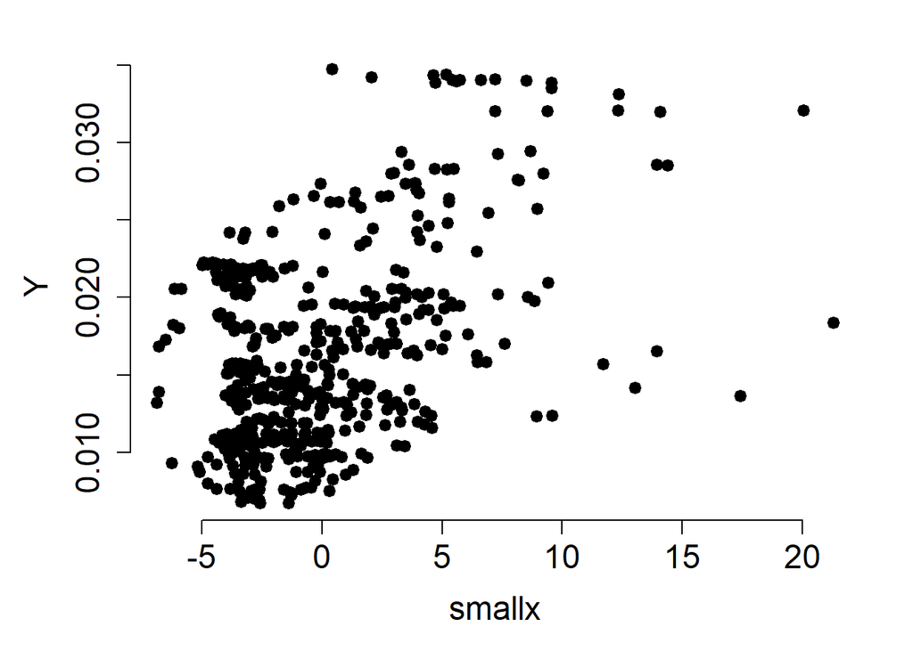

```r
par(lwd = 3, cex.axis = 1.5, cex.lab = 1.5, mar = c(5,5,2,2))
plot(Y~smallx, pch = 20, bty = "n", lwd = 5)
```

The graph doesn’t seem to be parabolic, so it doesn’t indicate interaction term at first glance.

We found from Part 2, that there is a relation between VIX.Close and AAPL.Vol, but now doing the same when VIX.Close is centered, we will test if there is any relation at all: * Null hypothesis $H_0: \beta_2 = 0$ * Alternate hypothesis $H_A: \beta_2 \neq 0$

Test statistic is $F_{obs} = \frac{MSR}{MSE} = \frac{SSR(x^2|x)/1}{SSE(x,x^2)/n-3}$

```r
curranova = anova(currmod)
curranova
```

|  | Df | Sum Sq | Mean Sq | F value | Pr(>F) |
| --- | --- | --- | --- | --- | --- |
| smallx | 1 | 4.371302e-03 | 4.371302e-03 | 140.16166346 | 1.119748e-28 |
| xsquare | 1 | 5.298070e-07 | 5.298070e-07 | 0.01698776 | 8.963521e-01 |
| Residuals | 500 | 1.559379e-02 | 3.118757e-05 | NA | NA |

```r
dfsse = n-3

## SSR is second value in Mean Sq column of the anova table
## SSE is bottom most value in Sum Sq column
Fobs = curranova[2,3] / ((curranova[3,2])/dfsse)
Fobs
```

```
## [1] 0.01698776
```

```r
#or could be taken from ANOVA table
Fobs2 = curranova[2,4]
Fobs2
```

```
## [1] 0.01698776
```

Our critical value is:

```r
alpha = 0.05

Fstar = qf(1 - alpha, 1, n-3)
Fstar
```

```
## [1] 3.860124
```

Our test statistic value is less than critical value, so we conclude that we fail to reject the null hypothesis.

Hence, the quadratic term $X^2$ for VIX.Close is not significant.

# AAPL.Vol vs AAPL.Ret higher order:

```r
currX = AAPL.Ret
n = length(AAPL.Vol)
Xbar = sum(AAPL.Ret)/n

#centering predictor variable

smallx = currX - Xbar

xsquare = smallx*smallx

currmod = lm(Y ~ smallx+xsquare)
summary(currmod)
```

```
##
## Call:
## lm(formula = Y ~ smallx + xsquare)
##
## Residuals:
##       Min        1Q    Median        3Q       Max
## -0.014072 -0.004654 -0.001502  0.003897  0.019557
##
## Coefficients:
##               Estimate Std. Error t value Pr(>|t|)
## (Intercept)  0.0158752  0.0002959  53.646  < 2e-16 ***
## smallx      -0.0593904  0.0161778  -3.671 0.000267 ***
## xsquare      1.1425422  0.3716630   3.074 0.002226 **
## ---
## Signif. codes:  0 '***' 0.001 '**' 0.01 '*' 0.05 '.' 0.1 ' ' 1
##
## Residual standard error: 0.006139 on 500 degrees of freedom
## Multiple R-squared:  0.05621,    Adjusted R-squared:  0.05244
## F-statistic: 14.89 on 2 and 500 DF,  p-value: 5.233e-07
```

Now plotting Y against X only:

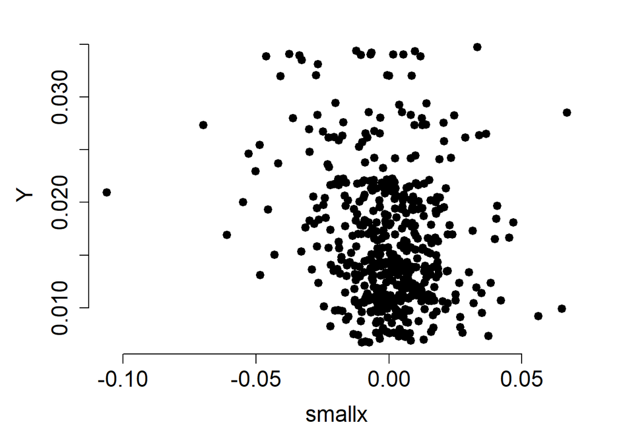

```r
par(lwd = 3, cex.axis = 1.5, cex.lab = 1.5, mar = c(5,5,2,2))
plot(Y~smallx, pch = 20, bty = "n", lwd = 5)
```

The graph doesn’t seem to be parabolic, so it doesn’t indicate interaction term at first glance.

We found from Part 2, that there is a relation between AAPL.Ret and AAPL.Vol, but now doing the same when AAPL.Ret is centered, we will test if there is any relation at all: * Null hypothesis $H_0: \beta_2 = 0$ * Alternate hypothesis $H_A: \beta_2 \neq 0$

Test statistic is $F_{obs} = \frac{MSR}{MSE} = \frac{SSR(x^2|x)/1}{SSE(x,x^2)/n-3}$

```r
curranova = anova(currmod)
curranova
```

|  | Df | Sum Sq | Mean Sq | F value | Pr(>F) |
| --- | --- | --- | --- | --- | --- |
| smallx | 1 | 0.0007661254 | 7.661254e-04 | 20.328812 | 8.132031e-06 |
| xsquare | 1 | 0.0003561507 | 3.561507e-04 | 9.450306 | 2.226493e-03 |
| Residuals | 500 | 0.0188433404 | 3.768668e-05 | NA | NA |

```r
dfsse = n-3

## SSR is second value in Mean Sq column of the anova table
## SSE is bottom most value in Sum Sq column
Fobs = curranova[2,3] / ((curranova[3,2])/dfsse)
Fobs
```

```
## [1] 9.450306
```

```r
#or could be taken from ANOVA table
Fobs2 = curranova[2,4]
Fobs2
```

```
## [1] 9.450306
```

Our critical value is:

```r
alpha = 0.05

Fstar = qf(1 - alpha, 1, n-3)
Fstar
```

```
## [1] 3.860124
```

Hence, the quadratic term $X^2$ for AAPL.Ret is significant

# AAPL.Vol vs AMZN.Ret higher order:

```r
currX = AMZN.Ret
n = length(AAPL.Vol)
Xbar = sum(AMZN.Ret)/n

#centering predictor variable

smallx = currX - Xbar

xsquare = smallx*smallx

currmod = lm(Y ~ smallx+xsquare)
summary(currmod)
```

```
##
## Call:
## lm(formula = Y ~ smallx + xsquare)
##
## Residuals:
##       Min        1Q    Median        3Q       Max
## -0.014725 -0.004525 -0.001245  0.003449  0.018966
##
## Coefficients:
##              Estimate Std. Error t value Pr(>|t|)
## (Intercept)  0.015252   0.000289  52.778  < 2e-16 ***
## smallx      -0.016177   0.013952  -1.159    0.247
## xsquare      2.677416   0.327522   8.175 2.46e-15 ***
## ---
## Signif. codes:  0 '***' 0.001 '**' 0.01 '*' 0.05 '.' 0.1 ' ' 1
##
## Residual standard error: 0.005912 on 500 degrees of freedom
## Multiple R-squared:  0.1248, Adjusted R-squared:  0.1213
## F-statistic: 35.66 on 2 and 500 DF,  p-value: 3.333e-15
```

Now plotting Y against X only:

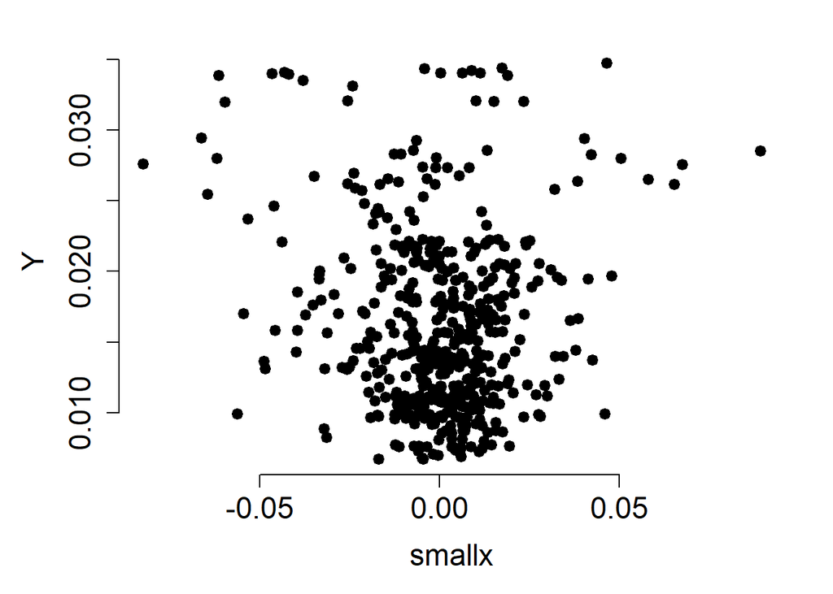

```r
par(lwd = 3, cex.axis = 1.5, cex.lab = 1.5, mar = c(5,5,2,2))
plot(Y~smallx, pch = 20, bty = "n", lwd = 5)
```

The graph doesn’t seem to be parabolic, so it doesn’t indicate interaction term at first glance.

We found from Part 2, that there is a relation between AMZN.Ret and AAPL.Vol, but now doing the same when AMZN.Ret is centered, we will test if there is any relation at all: * Null hypothesis $H_0: \beta_2 = 0$ * Alternate hypothesis $H_A: \beta_2 \neq 0$

Test statistic is $F_{obs} = \frac{MSR}{MSE} = \frac{SSR(x^2|x)/1}{SSE(x,x^2)/n-3}$

```r
curranova = anova(currmod)
curranova
```

|  | Df | Sum Sq | Mean Sq | F value | Pr(>F) |
| --- | --- | --- | --- | --- | --- |
| smallx | 1 | 0.0001569887 | 1.569887e-04 | 4.492254 | 3.454090e-02 |
| xsquare | 1 | 0.0023353657 | 2.335366e-03 | 66.826836 | 2.455495e-15 |
| Residuals | 500 | 0.0174732622 | 3.494652e-05 | NA | NA |

```r
dfsse = n-3

## SSR is second value in Mean Sq column of the anova table
## SSE is bottom most value in Sum Sq column
Fobs = curranova[2,3] / ((curranova[3,2])/dfsse)
Fobs
```

```
## [1] 66.82684
```

```r
#or could be taken from ANOVA table
Fobs2 = curranova[2,4]
Fobs2
```

```
## [1] 66.82684
```

Our critical value is:

```r
alpha = 0.05

Fstar = qf(1 - alpha, 1, n-3)
Fstar
```

```
## [1] 3.860124
```

Our test statistic value is *much* greater than critical value, so we conclude that we reject the null hypothesis.

Hence, the quadratic term $X^2$ for AMZN.Ret is quite significant.

# AAPL.Vol vs GSPC.Ret higher order:

```r
currX = GSPC.Ret
n = length(AAPL.Vol)
Xbar = sum(GSPC.Ret)/n

#centering predictor variable

smallx = currX - Xbar

xsquare = smallx*smallx

currmod = lm(Y ~ smallx+xsquare)
summary(currmod)
```

```
##
## Call:
## lm(formula = Y ~ smallx + xsquare)
##
## Residuals:
##       Min        1Q    Median        3Q       Max
## -0.014347 -0.004640 -0.001417  0.003814  0.018906
##
## Coefficients:
##               Estimate Std. Error t value Pr(>|t|)
## (Intercept)  0.0156042  0.0002964  52.638  < 2e-16 ***
## smallx      -0.0527817  0.0298301  -1.769   0.0774 .
## xsquare      6.9330205  1.3317649   5.206 2.82e-07 ***
## ---
## Signif. codes:  0 '***' 0.001 '**' 0.01 '*' 0.05 '.' 0.1 ' ' 1
##
## Residual standard error: 0.006095 on 500 degrees of freedom
## Multiple R-squared:  0.0698, Adjusted R-squared:  0.06608
## F-statistic: 18.76 on 2 and 500 DF,  p-value: 1.394e-08
```

Now plotting Y against X only:

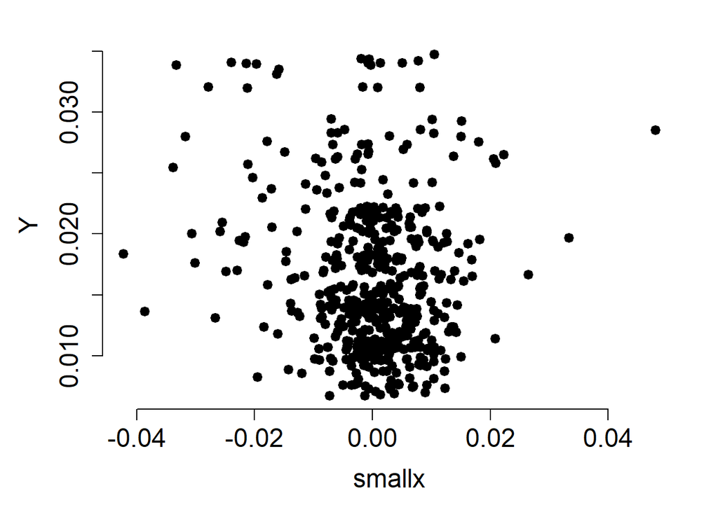

```r
par(lwd = 3, cex.axis = 1.5, cex.lab = 1.5, mar = c(5,5,2,2))
plot(Y~smallx, pch = 20, bty = "n", lwd = 5)
```

The graph doesn’t seem to be parabolic, so it doesn’t indicate interaction term at first glance.

We found from Part 2, that there is a relation between GSPC.Ret and AAPL.Vol, but now doing the same when GSPC.Ret is centered, we will test if there is any relation at all: * Null hypothesis $H_0: \beta_2 = 0$ * Alternate hypothesis $H_A: \beta_2 \neq 0$

Test statistic is $F_{obs} = \frac{MSR}{MSE} = \frac{SSR(x^2|x)/1}{SSE(x,x^2)/n-3}$

```r
curranova = anova(currmod)
curranova
```

|  | Df | Sum Sq | Mean Sq | F value | Pr(>F) |
| --- | --- | --- | --- | --- | --- |
| smallx | 1 | 0.0003869034 | 3.869034e-04 | 10.41628 | 1.331042e-03 |
| xsquare | 1 | 0.0010066533 | 1.006653e-03 | 27.10128 | 2.824624e-07 |
| Residuals | 500 | 0.0185720598 | 3.714412e-05 | NA | NA |

```r
dfsse = n-3

## SSR is second value in Mean Sq column of the anova table
## SSE is bottom most value in Sum Sq column
Fobs = curranova[2,3] / ((curranova[3,2])/dfsse)
Fobs
```

```
## [1] 27.10128
```

```r
#or could be taken from ANOVA table
Fobs2 = curranova[2,4]
Fobs2
```

```
## [1] 27.10128
```

Our critical value is:

```r
alpha = 0.05

Fstar = qf(1 - alpha, 1, n-3)
Fstar
```

```
## [1] 3.860124
```

Our test statistic value is quite greater than critical value, so we conclude that we reject the null hypothesis.

Hence, the quadratic term $X^2$ for GSPC.Ret is significant.